# Arda48GProject (2) (1) (2) (2) (1) (1) (6) (17)

## AD48G Term Project

Eda Bayrak – 2020300048  
Kemal Arda Elaman – 2020300129

## Abstract

The relationship between high-tech exports and these explanatory variables is explored through various analytical methods, including Elastic Net regularization, decision tree analysis, k-means clustering, and principal component analysis (PCA). These complementary approaches enable the identification of the most influential variables across different domains.

Findings from the analysis underscore the critical role of R&D expenditure, trade openness, control of corruption, and GDP per capita in accounting for cross-country variation in high-technology export performance.

## Introduction

High-technology exports constitute a critical indicator of a country’s position in the global economic landscape, both in the present and the future. As a direct reflection of the level of high-tech production and the international demand for it, high-tech exports provide valuable insights into a nation’s technological capacity and its contribution to economic growth through external trade. In this context, our research aims to identify the key factors that promote the expansion of high-technology exports.

Given the objective of uncovering the determinants of high-tech export performance, the study emphasizes variables related to production and trade. To minimize the confounding influence of cultural, institutional, or demographic differences, the analysis is limited to European countries. The dataset comprises macroeconomic, technological, political, and commercial indicators from 2012 to 2021.

A range of machine learning and statistical methods were employed to ensure a robust, multi-dimensional analytical approach. By using this diverse methodology, the research identifies the primary drivers of high-tech exports and integrates insights across models to enrich interpretation and explanatory power.

The key objectives of the study are as follows: (1) to determine which macro-level variables are most strongly associated with high-tech export performance, (2) to cluster European countries based on these explanatory factors and explore the common characteristics within each group, (3) to track and compare the evolution of countries’ positions with respect to these variables over the period 2012–2021.

## About the Dataset

The dataset is structured in a long format, where each row corresponds to a country-indicator combination, and yearly values are provided across multiple columns. We focus on a selected set of indicators relevant to high-technology export performance. Key variables include:

*The dependent variable:*

- High-technology exports (current US$)

*Innovation and economic indicators:*

- Research and development expenditure (% of GDP)
- Researchers in R&D (per million people)
- Adjusted net national income per capita (current US$)

*Governance and institutional quality:*

- Control of corruption

*Human capital and infrastructure:*

- Technicians in R&D (per million people)
- Self-employed, total (% of total employment) (modeled ILO estimate)
- Population ages 15-64 (% of total population)

After preprocessing and feature engineering (e.g., combining patent indicators), the dataset was used for modeling and clustering.

## Methods

##### 1. Data Collection and Preprocessing

- Raw data was collected and transformed using packages such as data.table, dplyr.
- The dataset was reshaped into a panel data structure, organized by country and year.
- Missing values were handled and numeric variables were normalized to ensure comparability.

##### 2. Exploratory Data Analysis (EDA)

- Initial data exploration was conducted through descriptive statistics and visualizations using ggplot2 and patchworks.
- Time trends, distribution patterns, and correlation matrices were evaluated to gain insights into the structure of the dataset.

##### 3. Feature Selection with Elastic Net

- All features were initially tested via the elastic net regression model using the glmnet package.
- A second model was built using model.matrix() to include country and year dummies explicitly.
- Cross-validation and model performance checks were performed.
- Variables with high predictive power were selected based on coefficient magnitudes.

##### 4. Correlation and Coefficient Alignment

- For selected features, correlation signs were compared with coefficient directions in the model.
- Variables with high correlation but conflicting coefficient signs, or with near-zero coefficients, were dropped.
- This refinement step improved both the interpretability and predictive robustness of the model.

##### 5. Panel Data Modeling

- A Fixed Effects (FE) panel model was constructed using the plm package based on the cleaned feature set.
- Robust standard errors were computed via vcovHC to address potential heteroskedasticity.
- Model outputs were interpreted in the context of within-country variations over time.

##### 6. Multicollinearity Control with VIF

- Multicollinearity among remaining predictors was assessed using the Variance Inflation Factor (VIF).
- Variables with excessively high VIF values were excluded from the final set to prevent instability.
- A refined FE model was re-estimated and results were benchmarked against the initial model.

##### 7. Decision Tree Modeling

- A decision tree model was fitted using rpart to identify non-linear relationships and rule-based splits.
- The tree was visualized with rpart.plot to highlight variable importance and cutoff points.

##### 8. Clustering Analysis

- Optimal number of clusters was identified using the elbow method.
- K-means clustering was applied and results were visualized using fviz_cluster().
- Countries were grouped into three economic innovation profiles, and each cluster’s traits were described.
- Clustering results were also cross-validated with PCA dimensions for interpretability.

##### 9. Principal Component Analysis (PCA)

- Dimensionality reduction was conducted using PCA.
- Principal components such as Dim.1 and Dim.2 were interpreted based on their loadings.
- PCA helped visualize country positions in a reduced feature space and interpret variance-explaining features.

## Outline of the Research

##### 1. Data Collection and Preprocessing

##### 2. Visual Inspection of the Dataset

##### 3. Elastic Net Analysis Including All Features

##### 4. Elastic Net Analysis with Selected Features and Country/Year dummies

##### 5. PLM with excluded variables based on Model Coefficients and Correlations

##### 6. Multicollinearity Control with VIF

##### 7. Decision Tree Analysis

##### 8. Clustering Analysis

##### 9. Principal Component Analysis (PCA)

### Codes

#### Installing necessary packages

```r
install.packages(c("tidyverse", "readxl", "data.table", "httr"))
install.packages("ggplot2")
install.packages("sf")
install.packages("rnaturalearth", repos = "http://cran.us.r-project.org")
install.packages("magrittr", repos = "http://cran.us.r-project.org")
install.packages("rnaturalearthdata", repos = "http://cran.us.r-project.org")
install.packages("heatmaply")
install.packages("patchwork")
```

#### Calling libraries

```r
library(readxl)
library(ggplot2)
library(stringr)
library(data.table)
library(dplyr)
library(tidyr)
library(tibble)
library(magrittr)
library(BBmisc)
library(plotly)
library(corrplot)
library(pheatmap)
library(heatmaply)
library(formattable)
library(knitr)
library(kableExtra)
library(patchwork)
library(circlize)
library(sf)
library(rnaturalearth)
library(rnaturalearthdata)
library(glmnet)
library(caret)
library(plm)
library(car)
library(rpart)
library(rpart.plot)
library(cluster)
library(factoextra)
library(FactoMineR)
library(NbClust)
library(HDclassif)
library(fastcluster)
library(vegan)
library(compareGroups)
library(broom)
library(IRdisplay)
library(listviewer)
library(microbenchmark)
library(httr)
```

### 1. Data Collection and Preprocessing

```r
# the link to the github page containing the dataset
wdi_link <- "https://github.com/bbayrakeda/HighTech/raw/refs/heads/main/data%20wdi.xlsx"

temp_file <- tempfile(fileext = ".xlsx")

req <- GET(wdi_link,
           authenticate(Sys.getenv("GITHUB_PAT"), ""),
           write_disk(path = temp_file))

wdidata <- readxl::read_excel(temp_file)

# printing the first six observations
head(wdidata)
```

A tibble: 6 × 14

| Country Name <chr> | Country Code <chr> | Series Name <chr> | Series Code <chr> | 2012 [YR2012] <chr> | 2013 [YR2013] <chr> | 2014 [YR2014] <chr> | 2015 [YR2015] <chr> | 2016 [YR2016] <chr> | 2017 [YR2017] <chr> | 2018 [YR2018] <chr> | 2019 [YR2019] <chr> | 2020 [YR2020] <chr> | 2021 [YR2021] <chr> |
| --- | --- | --- | --- | --- | --- | --- | --- | --- | --- | --- | --- | --- | --- |
| Austria | AUT | Adjusted net national income per capita (current US$) | NY.ADJ.NNTY.PC.CD | 39980.630839288679 | 41694.071408686832 | 42465.766605579382 | 35811.6857751508 | 37196.167747422478 | 38441.732718549421 | 41651.80739037021 | 40712.575341249358 | 39515.55740699578 | 43281.733479746137 |
| Bulgaria | BGR | Adjusted net national income per capita (current US$) | NY.ADJ.NNTY.PC.CD | 6243.7239786539567 | 6422.0104449370037 | 6643.0958853767297 | 5819.8776244347337 | 6238.0549366984051 | 6970.9555144899186 | 7752.8228979676687 | 8165.632881196876 | 8311.2539572722144 | 10114.523521391857 |
| Croatia | HRV | Adjusted net national income per capita (current US$) | NY.ADJ.NNTY.PC.CD | 10625.544896507861 | 11265.009646669139 | 11306.577671131245 | 10121.649648827824 | 10404.45543184067 | 11582.540419918954 | 12984.303682570562 | 13113.761304144487 | 12231.389313062215 | 14553.484213577225 |
| Czechia | CZE | Adjusted net national income per capita (current US$) | NY.ADJ.NNTY.PC.CD | 14334.344304900158 | 14511.85954983474 | 14284.856685489418 | 12903.368094770947 | 13479.639182783772 | 15315.252111987251 | 17451.20066787583 | 17471.655286562054 | 16844.235107959368 | 19843.782905674994 |
| Estonia | EST | Adjusted net national income per capita (current US$) | NY.ADJ.NNTY.PC.CD | 13778.337233375392 | 15315.388435920795 | 16276.91132775911 | 14040.886020332035 | 14872.602416664362 | 16600.900748468935 | 18854.373307904145 | 19062.769488820693 | 19133.100649843327 | 22462.364753587786 |
| France | FRA | Adjusted net national income per capita (current US$) | NY.ADJ.NNTY.PC.CD | 34394.693438084651 | 35878.042245396718 | 36234.531197758013 | 30908.686330464898 | 31203.694850268956 | 32666.612561874066 | 34960.740756656938 | 33898.516798709978 | 31908.098224116737 | 36447.57846210264 |

```r
print(names(wdidata))
```

```
 [1] "Country Name"  "Country Code"  "Series Name"   "Series Code"
 [5] "2012 [YR2012]" "2013 [YR2013]" "2014 [YR2014]" "2015 [YR2015]"
 [9] "2016 [YR2016]" "2017 [YR2017]" "2018 [YR2018]" "2019 [YR2019]"
[13] "2020 [YR2020]" "2021 [YR2021]"
```

#### Seting names and years

```r
setnames(wdidata, old = c("Country Name", "Country Code", "Series Name", "Series Code"),
         new = c("countryname", "countrycode", "seriesname", "seriescode"))
year_columns <- names(wdidata)[grep("\\[YR", names(wdidata))]
```

#### Data Melting

```r
melted_wdi <- melt(as.data.table(wdidata),
                    id.vars = c("countryname", "countrycode", "seriesname", "seriescode"),
                    measure.vars = year_columns,
                    variable.name = "year",
                    value.name = "value")

head(melted_wdi)
```

A data.table: 6 × 6

| countryname <chr> | countrycode <chr> | seriesname <chr> | seriescode <chr> | year <fct> | value <chr> |
| --- | --- | --- | --- | --- | --- |
| Austria | AUT | Adjusted net national income per capita (current US$) | NY.ADJ.NNTY.PC.CD | 2012 [YR2012] | 39980.630839288679 |
| Bulgaria | BGR | Adjusted net national income per capita (current US$) | NY.ADJ.NNTY.PC.CD | 2012 [YR2012] | 6243.7239786539567 |
| Croatia | HRV | Adjusted net national income per capita (current US$) | NY.ADJ.NNTY.PC.CD | 2012 [YR2012] | 10625.544896507861 |
| Czechia | CZE | Adjusted net national income per capita (current US$) | NY.ADJ.NNTY.PC.CD | 2012 [YR2012] | 14334.344304900158 |
| Estonia | EST | Adjusted net national income per capita (current US$) | NY.ADJ.NNTY.PC.CD | 2012 [YR2012] | 13778.337233375392 |
| France | FRA | Adjusted net national income per capita (current US$) | NY.ADJ.NNTY.PC.CD | 2012 [YR2012] | 34394.693438084651 |

```r
# Shortening the year values to 4 digits
setDT(melted_wdi)
melted_wdi <- melted_wdi[, year := substr(year, 1, 4)]

head(melted_wdi)
```

A data.table: 6 × 6

| countryname <chr> | countrycode <chr> | seriesname <chr> | seriescode <chr> | year <chr> | value <chr> |
| --- | --- | --- | --- | --- | --- |
| Austria | AUT | Adjusted net national income per capita (current US$) | NY.ADJ.NNTY.PC.CD | 2012 | 39980.630839288679 |
| Bulgaria | BGR | Adjusted net national income per capita (current US$) | NY.ADJ.NNTY.PC.CD | 2012 | 6243.7239786539567 |
| Croatia | HRV | Adjusted net national income per capita (current US$) | NY.ADJ.NNTY.PC.CD | 2012 | 10625.544896507861 |
| Czechia | CZE | Adjusted net national income per capita (current US$) | NY.ADJ.NNTY.PC.CD | 2012 | 14334.344304900158 |
| Estonia | EST | Adjusted net national income per capita (current US$) | NY.ADJ.NNTY.PC.CD | 2012 | 13778.337233375392 |
| France | FRA | Adjusted net national income per capita (current US$) | NY.ADJ.NNTY.PC.CD | 2012 | 34394.693438084651 |

#### Unique series of the Dataset

```r
# Creating a new variable with unique variable names
unique_series_names <- unique(melted_wdi$`seriesname`)

# Finding the length of the series
num_unique_series_names <- length(unique_series_names)

print(num_unique_series_names)
print(unique_series_names)
```

```
[1] 31
 [1] "Adjusted net national income per capita (current US$)"
 [2] "Bank nonperforming loans to total gross loans (%)"
 [3] "Control of Corruption: Estimate"
 [4] "Export unit value index (2015 = 100)"
 [5] "Foreign direct investment, net inflows (% of GDP)"
 [6] "GDP per capita growth (annual %)"
 [7] "GDP per capita, PPP (constant 2021 international $)"
 [8] "GDP per person employed (constant 2021 PPP $)"
 [9] "Gross fixed capital formation (constant 2015 US$)"
[10] "High-technology exports (% of manufactured exports)"
[11] "High-technology exports (current US$)"
[12] "Logistics performance index: Overall (1=low to 5=high)"
[13] "Patent applications, nonresidents"
[14] "Patent applications, residents"
```

[output cut: 17 more lines]

#### Transforming the Data into Wide Format

```r
wdi_wide <- melted_wdi %>%
  pivot_wider(
    names_from = seriesname,
    values_from = value,
    id_cols = c(countryname, countrycode, year)
  )

head(wdi_wide)
```

A tibble: 6 × 34

| countryname <chr> | countrycode <chr> | year <chr> | Adjusted net national income per capita (current US$) <chr> | Bank nonperforming loans to total gross loans (%) <chr> | Control of Corruption: Estimate <chr> | Export unit value index (2015 = 100) <chr> | Foreign direct investment, net inflows (% of GDP) <chr> | GDP per capita growth (annual %) <chr> | GDP per capita, PPP (constant 2021 international $) <chr> | ⋯ | Taxes less subsidies on products (constant LCU) <chr> | Taxes less subsidies on products (current LCU) <chr> | Taxes less subsidies on products (current US$) <chr> | Taxes on goods and services (% of revenue) <chr> | Taxes on goods and services (% value added of industry and services) <chr> | Taxes on goods and services (current LCU) <chr> | Technicians in R&D (per million people) <chr> | Trade (% of GDP) <chr> | Trademark applications, nonresident, by count <chr> | Trademark applications, resident, by count <chr> |
| --- | --- | --- | --- | --- | --- | --- | --- | --- | --- | --- | --- | --- | --- | --- | --- | --- | --- | --- | --- | --- |
| Austria | AUT | 2012 | 39980.630839288679 | 2.8133647663054502 | 1.4272544384002701 | 114 | 1.2830027920872027 | 0.17048863441917206 | 61451.549024420616 | ⋯ | 37217452000 | 35516756000 | 45631525770.548447 | 27.562015176057631 | 14.126984916088462 | 39073040000 | .. | 105.84079138970569 | 9465 | 17304 |
| Bulgaria | BGR | 2012 | 6243.7239786539567 | 16.6263209293069 | -0.281460791826248 | 124.3 | 3.293739963738898 | 1.3340660947645802 | 22611.306623731383 | ⋯ | 13253662000 | 10747058000 | 7059750377.717927 | 45.383092137285864 | 16.80711232371236 | 11468262000 | .. | 123.97132271417431 | 4862 | 13416 |
| Croatia | HRV | 2012 | 10625.544896507861 | 14.5622704712966 | -2.5457292795181299E-2 | 122.8 | 2.5456994844001359 | -1.7890550571017911 | 28262.518554490467 | ⋯ | 8425304951.6376991 | 7102122700 | 9124810267.0971603 | 48.656071965946062 | 20.890650556253661 | 7566895000 | 617.10319000000004 | 79.00226696471681 | 14663 | 4388 |
| Czechia | CZE | 2012 | 14334.344304900158 | 5.3516796726528701 | 0.31017965078353898 | 112.2 | 4.4842438075986895 | -0.909418373536937 | 39347.049299011815 | ⋯ | 429111009000 | 411400000000 | 21013919039.713955 | 30.89468130486518 | 11.419501482540216 | 412824000000 | 1739.6252999999999 | 145.48019539693462 | 6573 | 29563 |
| Estonia | EST | 2012 | 13778.337233375392 | 2.6226685940629699 | 1.0882983207702599 | 120.4 | 7.6916567949516015 | 4.0437743031622944 | 34115.362216866546 | ⋯ | 2557413000 | 2332044000 | 2996183713.5140634 | 37.482688824970708 | 16.245842648663032 | 2462950000 | 708.90950999999995 | 169.15606777386455 | 3592 | 1684 |
| France | FRA | 2012 | 34394.693438084651 | 4.2945232736967904 | 1.4719694852828999 | 113.9 | 1.2279007151938164 | -0.29959872325491688 | 49935.626913624437 | ⋯ | 234433081000 | 221570100000 | 284670754506.211 | 21.981074317842765 | 10.977308505515843 | 201417200000 | 1874.23047 | 61.658957077110152 | .. | .. |

```r
setnames(wdi_wide, old = "High-technology exports (current US$)",
         new = "hightechexports")

setnames(wdi_wide, old = "High-technology exports (% of manufactured exports)",
         new = "hightechexportsratio")
```

```r
print(names(wdi_wide))
```

```
 [1] "countryname"
 [2] "countrycode"
 [3] "year"
 [4] "Adjusted net national income per capita (current US$)"
 [5] "Bank nonperforming loans to total gross loans (%)"
 [6] "Control of Corruption: Estimate"
 [7] "Export unit value index (2015 = 100)"
 [8] "Foreign direct investment, net inflows (% of GDP)"
 [9] "GDP per capita growth (annual %)"
[10] "GDP per capita, PPP (constant 2021 international $)"
[11] "GDP per person employed (constant 2021 PPP $)"
[12] "Gross fixed capital formation (constant 2015 US$)"
[13] "hightechexportsratio"
[14] "hightechexports"
[15] "Logistics performance index: Overall (1=low to 5=high)"
```

[output cut: 19 more lines]

#### Converting columns to numeric

```r
wdi_wide_n <- wdi_wide %>%
  mutate(across(
    -c(countryname, countrycode, year),
    ~ suppressWarnings(as.numeric(.))
  ))

head(wdi_wide_n)
```

A tibble: 6 × 34

| countryname <chr> | countrycode <chr> | year <chr> | Adjusted net national income per capita (current US$) <dbl> | Bank nonperforming loans to total gross loans (%) <dbl> | Control of Corruption: Estimate <dbl> | Export unit value index (2015 = 100) <dbl> | Foreign direct investment, net inflows (% of GDP) <dbl> | GDP per capita growth (annual %) <dbl> | GDP per capita, PPP (constant 2021 international $) <dbl> | ⋯ | Taxes less subsidies on products (constant LCU) <dbl> | Taxes less subsidies on products (current LCU) <dbl> | Taxes less subsidies on products (current US$) <dbl> | Taxes on goods and services (% of revenue) <dbl> | Taxes on goods and services (% value added of industry and services) <dbl> | Taxes on goods and services (current LCU) <dbl> | Technicians in R&D (per million people) <dbl> | Trade (% of GDP) <dbl> | Trademark applications, nonresident, by count <dbl> | Trademark applications, resident, by count <dbl> |
| --- | --- | --- | --- | --- | --- | --- | --- | --- | --- | --- | --- | --- | --- | --- | --- | --- | --- | --- | --- | --- |
| Austria | AUT | 2012 | 39980.631 | 2.813365 | 1.42725444 | 114.0 | 1.283003 | 0.1704886 | 61451.55 | ⋯ | 37217452000 | 35516756000 | 45631525771 | 27.56202 | 14.12698 | 39073040000 | NA | 105.84079 | 9465 | 17304 |
| Bulgaria | BGR | 2012 | 6243.724 | 16.626321 | -0.28146079 | 124.3 | 3.293740 | 1.3340661 | 22611.31 | ⋯ | 13253662000 | 10747058000 | 7059750378 | 45.38309 | 16.80711 | 11468262000 | NA | 123.97132 | 4862 | 13416 |
| Croatia | HRV | 2012 | 10625.545 | 14.562270 | -0.02545729 | 122.8 | 2.545699 | -1.7890551 | 28262.52 | ⋯ | 8425304952 | 7102122700 | 9124810267 | 48.65607 | 20.89065 | 7566895000 | 617.1032 | 79.00227 | 14663 | 4388 |
| Czechia | CZE | 2012 | 14334.344 | 5.351680 | 0.31017965 | 112.2 | 4.484244 | -0.9094184 | 39347.05 | ⋯ | 429111009000 | 411400000000 | 21013919040 | 30.89468 | 11.41950 | 412824000000 | 1739.6253 | 145.48020 | 6573 | 29563 |
| Estonia | EST | 2012 | 13778.337 | 2.622669 | 1.08829832 | 120.4 | 7.691657 | 4.0437743 | 34115.36 | ⋯ | 2557413000 | 2332044000 | 2996183714 | 37.48269 | 16.24584 | 2462950000 | 708.9095 | 169.15607 | 3592 | 1684 |
| France | FRA | 2012 | 34394.693 | 4.294523 | 1.47196949 | 113.9 | 1.227901 | -0.2995987 | 49935.63 | ⋯ | 234433081000 | 221570100000 | 284670754506 | 21.98107 | 10.97731 | 201417200000 | 1874.2305 | 61.65896 | NA | NA |

#### Removing EUU and EMU data due to poor quality/missing values

```r
wdi_wide_n <- wdi_wide_n[!wdi_wide_n$countrycode %in% c("EUU", "EMU"), ]
```

#### NA Analysis and Summary of the Data

Several variables (10 out of 31) in the dataset contained missing values, with most having fewer than 20 NAs, though a few (e.g., Technicians in R&D) had over 100. To address this, missing values were imputed using medians. This method was chosen due to the presence of non-normal distributions and outliers in many variables such as FDI (% of GDP) and Bank nonperforming loans, which could bias the mean. Median imputation helped retain observations while reducing the influence of extreme values.

```r
wdi_wide_n %>% dplyr::select(where(is.numeric)) %>% summary()
```

```
 Adjusted net national income per capita (current US$)
 Min.   : 5820
 1st Qu.:15182
 Median :25349
 Mean   :30727
 3rd Qu.:41706
 Max.   :81276
 NA's   :10
 Bank nonperforming loans to total gross loans (%)
 Min.   : 0.1456
 1st Qu.: 2.0616
 Median : 3.6864
 Mean   : 7.0257
 3rd Qu.: 8.1860
 Max.   :47.7478
 NA's   :21
 Control of Corruption: Estimate Export unit value index (2015 = 100)
 Min.   :-0.3814                 Min.   : 74.6
 1st Qu.: 0.4308                 1st Qu.:103.3
 Median : 0.9737                 Median :112.8
 Mean   : 1.0820                 Mean   :112.8
 3rd Qu.: 1.8540                 3rd Qu.:119.7
 Max.   : 2.3994                 Max.   :159.3

 Foreign direct investment, net inflows (% of GDP)
 Min.   :-296.013
 1st Qu.:   1.162
 Median :   2.828
 Mean   :  14.738
 3rd Qu.:   5.226
 Max.   : 452.221

 GDP per capita growth (annual %)
 Min.   :-11.3741
 1st Qu.:  0.1827
 Median :  1.6715
 Mean   :  1.8942
 3rd Qu.:  3.9950
 Max.   : 23.4437

```

[output cut: 145 more lines]

```
 Min.   :  167
 1st Qu.: 3878
 Median : 5042
 Mean   : 9614
 3rd Qu.: 9226
 Max.   :70091
 NA's   :62
 Trademark applications, resident, by count
 Min.   :   405
 1st Qu.:  3726
 Median : 13262
 Mean   : 36474
 3rd Qu.: 31301
 Max.   :298103
 NA's   :62
```

```r
num_cols <- names(wdi_wide_n)[sapply(wdi_wide_n, is.numeric)]
num_cols <- setdiff(num_cols, "year")

for(col in num_cols) {
  wdi_wide_n[[col]][is.na(wdi_wide_n[[col]])] <- median(wdi_wide_n[[col]], na.rm = TRUE)
}
```

### 2. Visual Inspection of the Dataset

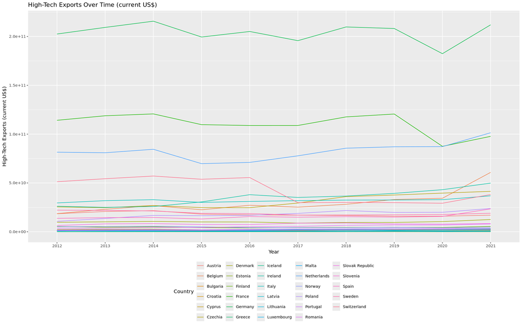

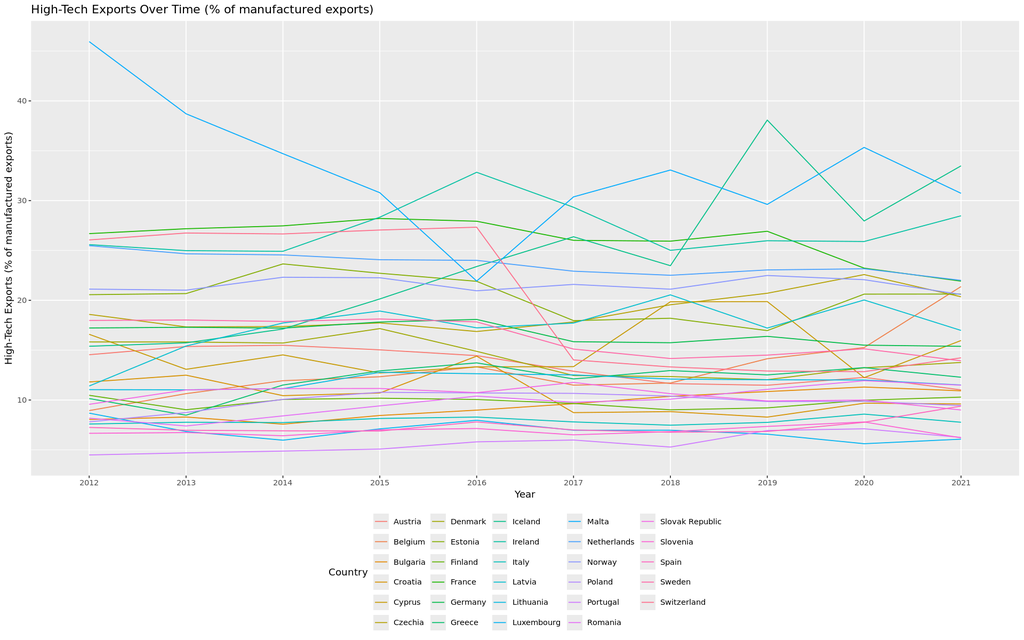

```r
options(repr.plot.width = 16, repr.plot.height = 10)

ggplot(wdi_wide_n, aes(x = year, y = hightechexports, color = countryname, group = countryname)) +
  geom_line() +
  labs(title = "High-Tech Exports Over Time (current US$)",
       x = "Year",
       y = "High-Tech Exports (current US$)",
       color = "Country") +
  theme(legend.position = "bottom")

ggplot(wdi_wide_n, aes(x = year, y = hightechexportsratio, color = countryname, group = countryname)) +
  geom_line() +
  labs(title = "High-Tech Exports Over Time (% of manufactured exports)",
       x = "Year",
       y = "High-Tech Exports (% of manufactured exports)",
       color = "Country") +
  theme(legend.position = "bottom")
```

#### High-Tech Exports Graphs for All Countries (2012,2017,2021)

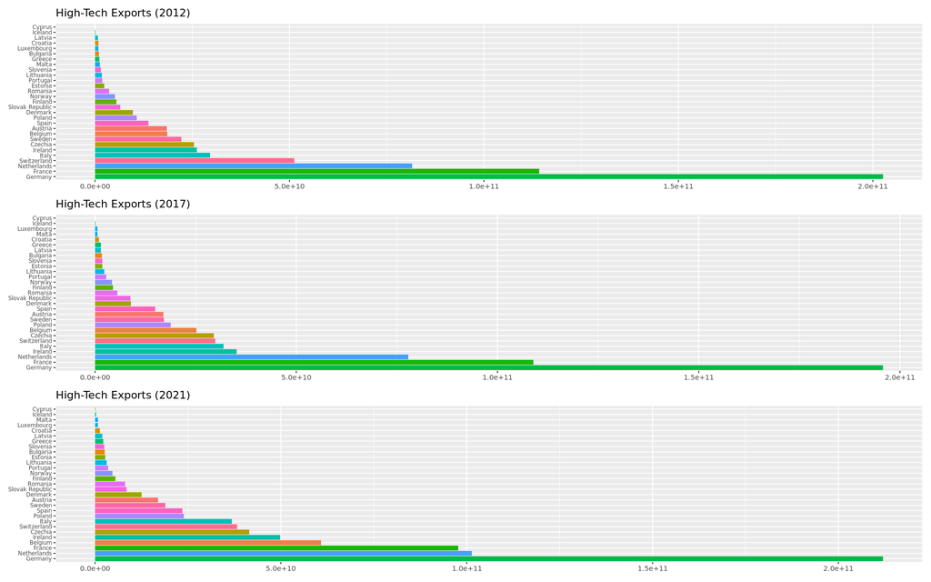

```r
# 2012
p1 <- ggplot(wdi_wide_n[wdi_wide_n$year == 2012, ],
             aes(x = reorder(countryname, -hightechexports),
                 y = hightechexports,
                 fill = countryname)) +
      geom_col() +
      coord_flip() +
      labs(title = "High-Tech Exports (2012)", x = NULL, y = NULL) +
      theme(legend.position = "none", axis.text.y = element_text(size = 7))

# 2017
p2 <- ggplot(wdi_wide_n[wdi_wide_n$year == 2017, ],
             aes(x = reorder(countryname, -hightechexports),
                 y = hightechexports,
                 fill = countryname)) +
      geom_col() +
      coord_flip() +
      labs(title = "High-Tech Exports (2017)", x = NULL, y = NULL) +
      theme(legend.position = "none", axis.text.y = element_text(size = 7))

# 2021
p3 <- ggplot(wdi_wide_n[wdi_wide_n$year == 2021, ],
             aes(x = reorder(countryname, -hightechexports),
                 y = hightechexports,
                 fill = countryname)) +
      geom_col() +
      coord_flip() +
      labs(title = "High-Tech Exports (2021)", x = NULL, y = NULL) +
      theme(legend.position = "none", axis.text.y = element_text(size = 7))

p1 / p2 / p3
```

#### High-Tech Exports Ratio Graphs for All Countries (2012,2017,2021)

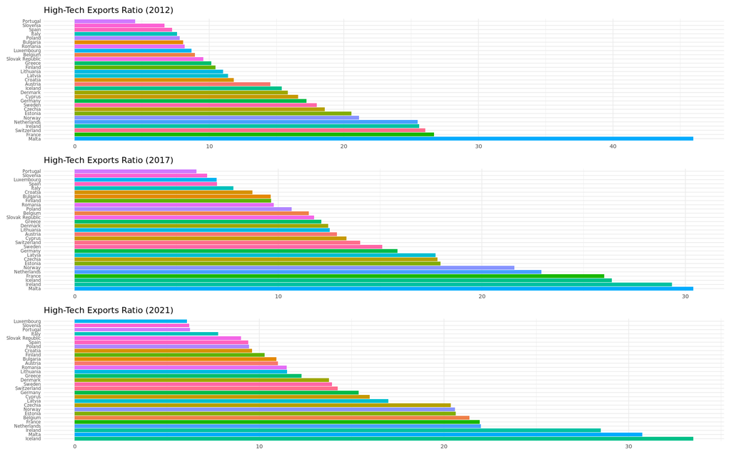

```r
# 2012
p1 <- ggplot(wdi_wide_n[wdi_wide_n$year == 2012, ],
             aes(x = reorder(countryname, -hightechexportsratio),
                 y = hightechexportsratio,
                 fill = countryname)) +
  geom_col() +
  coord_flip() +
  labs(title = "High-Tech Exports Ratio (2012)", x = NULL, y = NULL) +
  theme_minimal() +
  theme(legend.position = "none", axis.text.y = element_text(size = 7))

# 2017
p2 <- ggplot(wdi_wide_n[wdi_wide_n$year == 2017, ],
             aes(x = reorder(countryname, -hightechexportsratio),
                 y = hightechexportsratio,
                 fill = countryname)) +
  geom_col() +
  coord_flip() +
  labs(title = "High-Tech Exports Ratio (2017)", x = NULL, y = NULL) +
  theme_minimal() +
  theme(legend.position = "none", axis.text.y = element_text(size = 7))

# 2021
p3 <- ggplot(wdi_wide_n[wdi_wide_n$year == 2021, ],
             aes(x = reorder(countryname, -hightechexportsratio),
                 y = hightechexportsratio,
                 fill = countryname)) +
  geom_col() +
  coord_flip() +
  labs(title = "High-Tech Exports Ratio (2021)", x = NULL, y = NULL) +
  theme_minimal() +
  theme(legend.position = "none", axis.text.y = element_text(size = 7))

p1 / p2 / p3
```

#### High Tech Exports Values on the Map (2021)

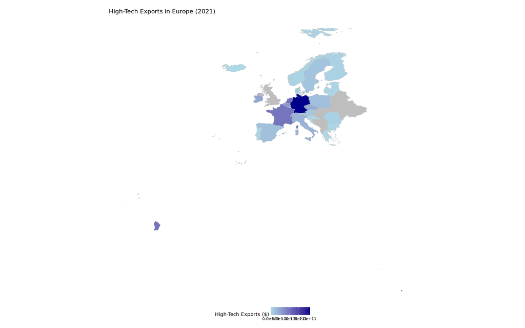

```r
hightech_wdi <- wdi_wide_n[c(1,2,3,14)]


world <- ne_countries(scale = "medium", returnclass = "sf")


europe <- world %>%
  filter(continent == "Europe") %>%
  filter(!sovereignt %in% c("Russia", "Turkey", "Kazakhstan", "Azerbaijan", "Armenia", "Georgia"))


euro_data_2021 <- hightech_wdi[hightech_wdi$year == 2021, ]


euro_data_2021$countryname <- as.character(euro_data_2021$countryname)


europe_data <- euro_data_2021 %>%
  filter(countryname %in% europe$sovereignt)


europe_map <- left_join(europe, europe_data, by = c("sovereignt" = "countryname"))


ggplot(europe_map) +
  geom_sf(aes(fill = hightechexports), color = "gray", size = 0.1) +
  scale_fill_gradient(low = "lightblue", high = "darkblue",
                      name = "High-Tech Exports ($)",
                      na.value = "gray",
                      limits = c(0, max(europe_map$hightechexports, na.rm = TRUE))) +
  labs(title = "High-Tech Exports in Europe (2021)", fill = "Export Value ($)") +
  theme_void() +
  theme(legend.position = "bottom",
        plot.margin = unit(c(0.5, 0.5, 0.5, 0.5), "cm")) +
  coord_sf(xlim = c(st_bbox(europe_map)$xmin, st_bbox(europe_map)$xmax),
           ylim = c(st_bbox(europe_map)$ymin, st_bbox(europe_map)$ymax))
```

#### High-Tech Exports Over Time by Country

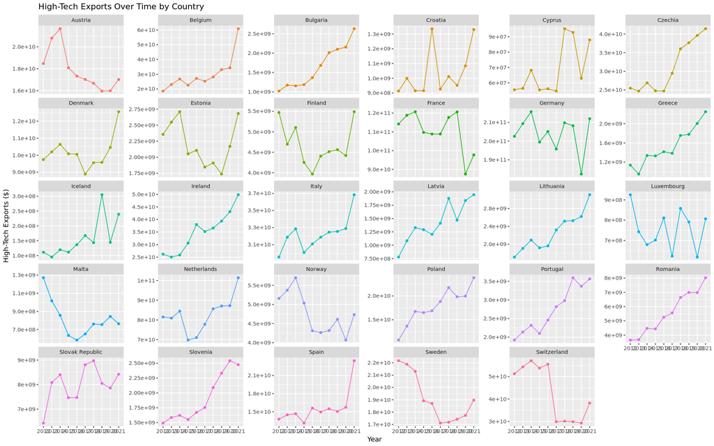

```r
wdi_year <- setorder(hightech_wdi, year)

wdi_year_ordered <- wdi_year %>%
  arrange(year, desc(hightechexports))


ggplot(wdi_year_ordered, aes(x = year, y = hightechexports, color = countryname, group = countryname)) +
  geom_line() +
  geom_point() +
  facet_wrap(~countryname, scales = "free_y") +
  labs(title = "High-Tech Exports Over Time by Country",
       x = "Year",
       y = "High-Tech Exports ($)") +
  theme(legend.position = "none")
```

#### Correlation Matrix

```r
matrix_df <- wdi_wide_n[, -c(1:3)]

cor_matrix <- cor(matrix_df)
cor_matrix
```

A matrix: 31 × 31 of type dbl

|  | Adjusted net national income per capita (current US$) | Bank nonperforming loans to total gross loans (%) | Control of Corruption: Estimate | Export unit value index (2015 = 100) | Foreign direct investment, net inflows (% of GDP) | GDP per capita growth (annual %) | GDP per capita, PPP (constant 2021 international $) | GDP per person employed (constant 2021 PPP $) | Gross fixed capital formation (constant 2015 US$) | hightechexportsratio | ⋯ | Taxes less subsidies on products (constant LCU) | Taxes less subsidies on products (current LCU) | Taxes less subsidies on products (current US$) | Taxes on goods and services (% of revenue) | Taxes on goods and services (% value added of industry and services) | Taxes on goods and services (current LCU) | Technicians in R&D (per million people) | Trade (% of GDP) | Trademark applications, nonresident, by count | Trademark applications, resident, by count |
| --- | --- | --- | --- | --- | --- | --- | --- | --- | --- | --- | --- | --- | --- | --- | --- | --- | --- | --- | --- | --- | --- |
| Adjusted net national income per capita (current US$) | 1.00000000 | -0.38942099 | 0.85504030 | 0.0211536006 | -0.038045324 | -0.15301893 | 0.87416328 | 0.78780884 | 0.21991790 | 0.28950823 | ⋯ | 0.299214207 | 0.289064924 | 0.13697728 | -0.424602261 | -0.39169301 | 0.3134987610 | 0.34464155 | 0.18877799 | 0.5089775097 | 0.079500277 |
| Bank nonperforming loans to total gross loans (%) | -0.38942099 | 1.00000000 | -0.46589706 | -0.0297354712 | 0.180643414 | -0.01209743 | -0.37526447 | -0.31468169 | -0.17399240 | -0.16076354 | ⋯ | -0.273465086 | -0.274644230 | -0.11663934 | 0.162977575 | 0.31165041 | -0.2751981404 | -0.23749971 | -0.13315533 | -0.2159522529 | -0.109963867 |
| Control of Corruption: Estimate | 0.85504030 | -0.46589706 | 1.00000000 | -0.0876887055 | -0.056660695 | -0.14370401 | 0.72312981 | 0.61614309 | 0.22485849 | 0.32124071 | ⋯ | 0.335244145 | 0.317829917 | 0.15750366 | -0.318179843 | -0.30236875 | 0.3294967958 | 0.27491323 | 0.11476501 | 0.3334208152 | 0.082000041 |
| Export unit value index (2015 = 100) | 0.02115360 | -0.02973547 | -0.08768871 | 1.0000000000 | 0.104725734 | 0.03018413 | -0.10825551 | -0.10057097 | -0.01235892 | -0.07143582 | ⋯ | -0.004118098 | 0.003500613 | 0.02610763 | -0.051813713 | 0.01157248 | -0.0003817144 | -0.13153424 | -0.05052722 | -0.0007388807 | 0.009423179 |
| Foreign direct investment, net inflows (% of GDP) | -0.03804532 | 0.18064341 | -0.05666069 | 0.1047257336 | 1.000000000 | 0.14756095 | 0.02426643 | -0.03305814 | -0.12246121 | 0.24019620 | ⋯ | -0.149724548 | -0.151048536 | -0.11604182 | 0.002584336 | -0.00488604 | -0.1485152468 | -0.08475942 | 0.23753553 | -0.1241252006 | -0.091948172 |
| GDP per capita growth (annual %) | -0.15301893 | -0.01209743 | -0.14370401 | 0.0301841301 | 0.147560949 | 1.00000000 | -0.03103727 | -0.04358720 | -0.13559081 | 0.10720149 | ⋯ | -0.106811587 | -0.095085399 | -0.13896552 | 0.175741702 | 0.02757572 | -0.0897939633 | -0.08699954 | 0.19055819 | -0.1236516007 | -0.115103235 |
| GDP per capita, PPP (constant 2021 international $) | 0.87416328 | -0.37526447 | 0.72312981 | -0.1082555137 | 0.024266431 | -0.03103727 | 1.00000000 | 0.95670870 | 0.14206553 | 0.21001464 | ⋯ | 0.153007050 | 0.147018539 | 0.06510526 | -0.431798556 | -0.41413380 | 0.1573520277 | 0.43156361 | 0.51801432 | 0.3295080961 | 0.033164629 |
| GDP per person employed (constant 2021 PPP $) | 0.78780884 | -0.31468169 | 0.61614309 | -0.1005709742 | -0.033058136 | -0.04358720 | 0.95670870 | 1.00000000 | 0.18157269 | 0.11403833 | ⋯ | 0.106402440 | 0.100005944 | 0.12433460 | -0.445499689 | -0.37509314 | 0.1036516490 | 0.43834731 | 0.50276713 | 0.2465612062 | 0.091418890 |
| Gross fixed capital formation (constant 2015 US$) | 0.21991790 | -0.17399240 | 0.22485849 | -0.0123589199 | -0.122461210 | -0.13559081 | 0.14206553 | 0.18157269 | 1.00000000 | 0.13635310 | ⋯ | 0.417308989 | 0.406469578 | 0.97554737 | -0.598548902 | -0.55465064 | 0.2571457509 | 0.18103211 | -0.35066906 | 0.4426357790 | 0.899436617 |
| hightechexportsratio | 0.28950823 | -0.16076354 | 0.32124071 | -0.0714358179 | 0.240196195 | 0.10720149 | 0.21001464 | 0.11403833 | 0.13635310 | 1.00000000 | ⋯ | 0.201980046 | 0.200797360 | 0.07462162 | -0.157675018 | -0.27805182 | 0.2046497026 | 0.04083751 | 0.11393561 | 0.1648638297 | 0.121447118 |
| hightechexports | 0.20640468 | -0.18353389 | 0.28418579 | -0.0299602262 | -0.092638259 | -0.07453513 | 0.16360184 | 0.15386188 | 0.90428471 | 0.27258840 | ⋯ | 0.375131790 | 0.361990982 | 0.88020138 | -0.535638323 | -0.53712917 | 0.2036853560 | 0.21144361 | -0.17724002 | 0.3697391066 | 0.782869637 |
| Logistics performance index: Overall (1=low to 5=high) | 0.42507377 | -0.29547237 | 0.46602086 | -0.1016866700 | -0.142331786 | -0.12186290 | 0.37981766 | 0.37800027 | 0.33309888 | 0.05948545 | ⋯ | 0.257955114 | 0.246685434 | 0.30790423 | -0.344176200 | -0.29313305 | 0.2241054061 | 0.22871153 | -0.03611808 | 0.2010223963 | 0.207306920 |
| Patent applications, nonresidents | 0.12550877 | -0.08806092 | 0.19956885 | -0.0180881380 | -0.047826973 | -0.07174894 | 0.10156542 | 0.07500319 | 0.76282684 | 0.06346657 | ⋯ | 0.320510103 | 0.308511102 | 0.76438727 | -0.355193124 | -0.36776597 | 0.1330059989 | 0.16432785 | -0.16466136 | 0.2923094847 | 0.622856120 |
| Patent applications, residents | 0.10104048 | -0.09953650 | 0.17387828 | -0.0182783877 | -0.071522023 | -0.09470160 | 0.06082550 | 0.06345466 | 0.87251355 | 0.07173995 | ⋯ | 0.370060573 | 0.356269493 | 0.88508753 | -0.421171737 | -0.39428640 | 0.1804831779 | 0.18116199 | -0.25907316 | 0.3013646737 | 0.760285978 |
| Political Stability and Absence of Violence/Terrorism: Estimate | 0.60928510 | -0.46607086 | 0.63594158 | -0.0434719033 | 0.069753946 | -0.02548353 | 0.57533295 | 0.43161207 | -0.20245613 | 0.26745045 | ⋯ | 0.155954522 | 0.144944902 | -0.25872813 | -0.083596162 | -0.18221261 | 0.1927162522 | 0.28020001 | 0.36376711 | 0.2168402030 | -0.292263432 |
| Population ages 15-64 (% of total population) | -0.05543770 | 0.21408871 | -0.17017888 | -0.0033843690 | 0.291390578 | 0.01595114 | 0.06690956 | -0.02121967 | -0.29626744 | -0.06942691 | ⋯ | -0.312216620 | -0.316046318 | -0.31043441 | -0.045830792 | -0.12306169 | -0.3059952743 | -0.01372024 | 0.44999089 | -0.0169540913 | -0.268873867 |
| Research and development expenditure (% of GDP) | 0.55836470 | -0.42004812 | 0.71409723 | -0.0492505247 | -0.231613417 | -0.22904955 | 0.34053450 | 0.29665591 | 0.38939204 | 0.10958409 | ⋯ | 0.490830071 | 0.477606551 | 0.35515348 | -0.307503297 | -0.18520677 | 0.4587331420 | 0.31814008 | -0.23770331 | 0.2718570798 | 0.246525728 |
| Researchers in R&D (per million people) | 0.70117193 | -0.45091692 | 0.82590740 | -0.0410332671 | -0.205649370 | -0.11732211 | 0.56212381 | 0.51290275 | 0.17409505 | 0.13666817 | ⋯ | 0.428234369 | 0.418485141 | 0.13549341 | -0.247568823 | -0.12683760 | 0.4415760712 | 0.26007350 | -0.02685351 | 0.2096049061 | 0.060733744 |
| Self-employed, total (% of total employment) (modeled ILO estimate) | -0.46056291 | 0.56917985 | -0.59212728 | 0.0378570219 | -0.005051024 | -0.03966740 | -0.41999412 | -0.29157235 | -0.11224864 | -0.25757380 | ⋯ | -0.249089218 | -0.227428620 | -0.07225367 | 0.010503581 | 0.09154589 | -0.2215920181 | -0.19734055 | -0.24404010 | -0.1492281711 | -0.081093009 |
| Tax revenue (% of GDP) | 0.24308784 | 0.14094256 | 0.22863343 | 0.0106427781 | 0.098885030 | -0.08453744 | 0.16849856 | 0.20121818 | -0.25260615 | 0.02727601 | ⋯ | 0.078367741 | 0.069640231 | -0.15605697 | 0.032359130 | 0.47869372 | 0.1513127020 | -0.04784975 | 0.05514979 | -0.4089182070 | -0.209710451 |
| Tax revenue (current LCU) | 0.38873379 | -0.27160898 | 0.38977873 | 0.0163548345 | -0.145067591 | -0.10141341 | 0.19895146 | 0.15136029 | 0.28234310 | 0.21699901 | ⋯ | 0.943218535 | 0.946745452 | 0.29019185 | -0.186722376 | -0.14549058 | 0.9741627704 | 0.06722795 | -0.35983562 | 0.1510113271 | 0.216678678 |
| Taxes less subsidies on products (constant LCU) | 0.29921421 | -0.27346509 | 0.33524415 | -0.0041180979 | -0.149724548 | -0.10681159 | 0.15300705 | 0.10640244 | 0.41730899 | 0.20198005 | ⋯ | 1.000000000 | 0.996054924 | 0.42837949 | -0.257351629 | -0.24024493 | 0.9739850501 | 0.12492405 | -0.36535269 | 0.1856392291 | 0.340178878 |
| Taxes less subsidies on products (current LCU) | 0.28906492 | -0.27464423 | 0.31782992 | 0.0035006131 | -0.151048536 | -0.09508540 | 0.14701854 | 0.10000594 | 0.40646958 | 0.20079736 | ⋯ | 0.996054924 | 1.000000000 | 0.41691736 | -0.247295414 | -0.23868983 | 0.9802287778 | 0.10909186 | -0.36988531 | 0.1836985226 | 0.333075262 |
| Taxes less subsidies on products (current US$) | 0.13697728 | -0.11663934 | 0.15750366 | 0.0261076335 | -0.116041825 | -0.13896552 | 0.06510526 | 0.12433460 | 0.97554737 | 0.07462162 | ⋯ | 0.428379486 | 0.416917362 | 1.00000000 | -0.565773531 | -0.43884608 | 0.2630458660 | 0.14743126 | -0.38162102 | 0.2970620970 | 0.890802059 |
| Taxes on goods and services (% of revenue) | -0.42460226 | 0.16297757 | -0.31817984 | -0.0518137131 | 0.002584336 | 0.17574170 | -0.43179856 | -0.44549969 | -0.59854890 | -0.15767502 | ⋯ | -0.257351629 | -0.247295414 | -0.56577353 | 1.000000000 | 0.74435219 | -0.1673347185 | -0.23544077 | -0.03158741 | -0.3550854641 | -0.506952598 |
| Taxes on goods and services (% value added of industry and services) | -0.39169301 | 0.31165041 | -0.30236875 | 0.0115724843 | -0.004886040 | 0.02757572 | -0.41413380 | -0.37509314 | -0.55465064 | -0.27805182 | ⋯ | -0.240244929 | -0.238689825 | -0.43884608 | 0.744352195 | 1.00000000 | -0.1674796787 | -0.19423817 | -0.11113891 | -0.5275219125 | -0.419716238 |
| Taxes on goods and services (current LCU) | 0.31349876 | -0.27519814 | 0.32949680 | -0.0003817144 | -0.148515247 | -0.08979396 | 0.15735203 | 0.10365165 | 0.25714575 | 0.20464970 | ⋯ | 0.973985050 | 0.980228778 | 0.26304587 | -0.167334719 | -0.16747968 | 1.0000000000 | 0.08102889 | -0.34869458 | 0.1529790128 | 0.196042193 |
| Technicians in R&D (per million people) | 0.34464155 | -0.23749971 | 0.27491323 | -0.1315342360 | -0.084759424 | -0.08699954 | 0.43156361 | 0.43834731 | 0.18103211 | 0.04083751 | ⋯ | 0.124924046 | 0.109091858 | 0.14743126 | -0.235440773 | -0.19423817 | 0.0810288898 | 1.00000000 | 0.23810631 | 0.1848446303 | 0.179640812 |
| Trade (% of GDP) | 0.18877799 | -0.13315533 | 0.11476501 | -0.0505272242 | 0.237535527 | 0.19055819 | 0.51801432 | 0.50276713 | -0.35066906 | 0.11393561 | ⋯ | -0.365352693 | -0.369885314 | -0.38162102 | -0.031587414 | -0.11113891 | -0.3486945837 | 0.23810631 | 1.00000000 | -0.2155066725 | -0.319558255 |
| Trademark applications, nonresident, by count | 0.50897751 | -0.21595225 | 0.33342082 | -0.0007388807 | -0.124125201 | -0.12365160 | 0.32950810 | 0.24656121 | 0.44263578 | 0.16486383 | ⋯ | 0.185639229 | 0.183698523 | 0.29706210 | -0.355085464 | -0.52752191 | 0.1529790128 | 0.18484463 | -0.21550667 | 1.0000000000 | 0.361664678 |
| Trademark applications, resident, by count | 0.07950028 | -0.10996387 | 0.08200004 | 0.0094231788 | -0.091948172 | -0.11510324 | 0.03316463 | 0.09141889 | 0.89943662 | 0.12144712 | ⋯ | 0.340178878 | 0.333075262 | 0.89080206 | -0.506952598 | -0.41971624 | 0.1960421928 | 0.17964081 | -0.31955825 | 0.3616646784 | 1.000000000 |

#### Correlation Heatmaps of Selected Countries (Germany, Romania, Spain)

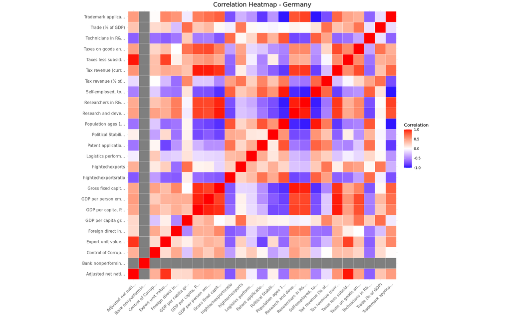

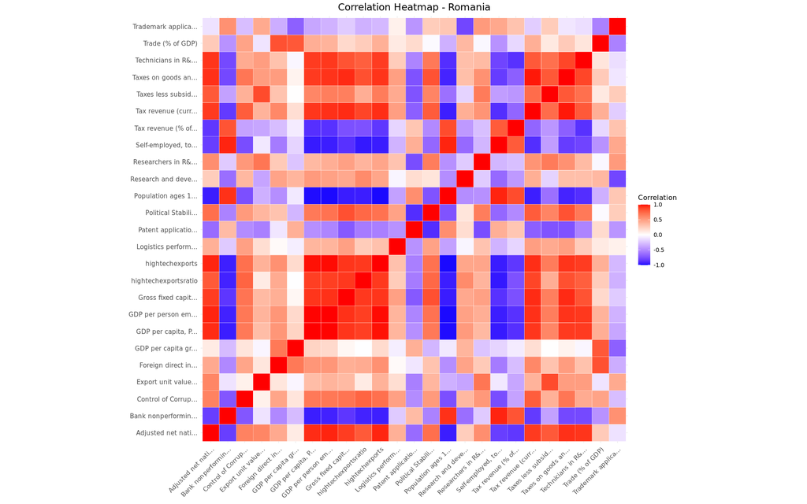

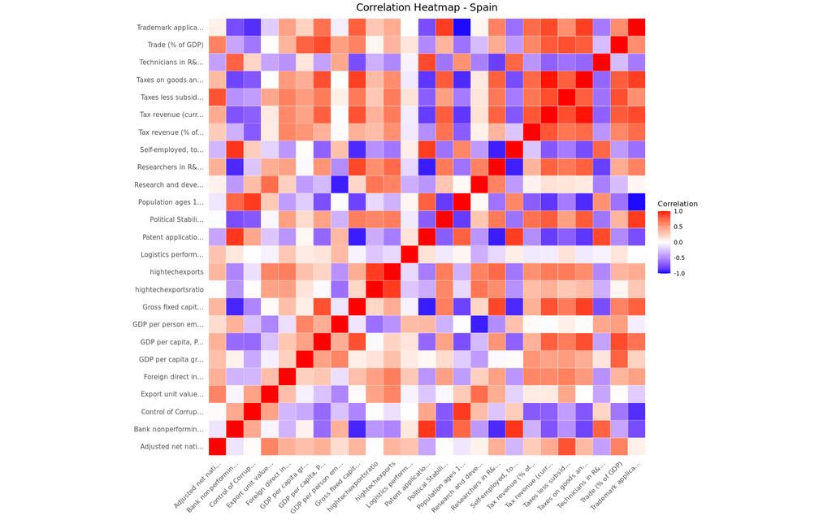

```r
df_ger <- wdi_wide_n %>%
  filter(countryname == "Germany")

df_ger <- df_ger[,-c(1,2,3)]

df_rom <- wdi_wide_n %>%
  filter(countryname == "Romania")

df_rom <- df_rom[,-c(1,2,3)]

df_esp <- wdi_wide_n %>%
  filter(countryname == "Spain")

df_esp <- df_esp[,-c(1,2,3)]


#Germany
colnames(df_ger) <- str_trunc(colnames(df_ger), width = 20, side = "right")

cor_matrix <- cor(df_ger, use = "complete.obs")

cor_melt <- melt(cor_matrix)

ggplot(cor_melt, aes(x = Var1, y = Var2, fill = value)) +
  geom_tile(color = "white") +
  scale_fill_gradient2(low = "blue", high = "red", mid = "white",
                       midpoint = 0, limit = c(-1,1),
                       name="Correlation") +
  theme_minimal(base_size = 10) +
  theme(
    axis.text.x = element_text(angle = 45, vjust = 1, hjust = 1, size = 9),
    axis.text.y = element_text(size = 9),
    plot.title = element_text(hjust = 0.5, size = 14),
    axis.title = element_blank()
  ) +
  coord_fixed() +
  labs(title = "Correlation Heatmap - Germany")

#Romania
colnames(df_rom) <- str_trunc(colnames(df_rom), width = 20, side = "right")

cor_matrix <- cor(df_rom, use = "complete.obs")

cor_melt <- melt(cor_matrix)

ggplot(cor_melt, aes(x = Var1, y = Var2, fill = value)) +
  geom_tile(color = "white") +
  scale_fill_gradient2(low = "blue", high = "red", mid = "white",
                       midpoint = 0, limit = c(-1,1),
                       name="Correlation") +
  theme_minimal(base_size = 10) +
  theme(
    axis.text.x = element_text(angle = 45, vjust = 1, hjust = 1, size = 9),
    axis.text.y = element_text(size = 9),
    plot.title = element_text(hjust = 0.5, size = 14),
    axis.title = element_blank()
  ) +
  coord_fixed() +
  labs(title = "Correlation Heatmap - Romania")

#Spain
colnames(df_esp) <- str_trunc(colnames(df_esp), width = 20, side = "right")

cor_matrix <- cor(df_esp, use = "complete.obs")

cor_melt <- melt(cor_matrix)

ggplot(cor_melt, aes(x = Var1, y = Var2, fill = value)) +
  geom_tile(color = "white") +
  scale_fill_gradient2(low = "blue", high = "red", mid = "white",
                       midpoint = 0, limit = c(-1,1),
                       name="Correlation") +
  theme_minimal(base_size = 10) +
  theme(
    axis.text.x = element_text(angle = 45, vjust = 1, hjust = 1, size = 9),
    axis.text.y = element_text(size = 9),
    plot.title = element_text(hjust = 0.5, size = 14),
    axis.title = element_blank()
  ) +
  coord_fixed() +
  labs(title = "Correlation Heatmap - Spain")
```

#### Column Renaming

To ease data analysis, we renamed columns as below

```r
new_colnames <- c(
  "countryname",
  "countrycode",
  "year",
  "adjusted_net_national_income_per_capita_usd",
  "bank_nonperforming_loans_percent",
  "control_of_corruption",
  "export_unit_value_index_2015",
  "fdi_net_inflows_percent_gdp",
  "gdp_per_capita_growth_percent",
  "gdp_per_capita_ppp_2021",
  "gdp_per_person_employed_ppp_2021",
  "gross_fixed_capital_formation_usd_2015",
  "hightechexportsratio",
  "hightechexports",
  "logistics_performance_index",
  "patent_applications_nonresidents",
  "patent_applications_residents",
  "political_stability",
  "population_ages_15_64_percent",
  "rd_expenditure_percent_gdp",
  "researchers_rd_per_million",
  "self_employed_percent_total_employment",
  "tax_revenue_percent_gdp",
  "tax_revenue_lcu",
  "taxes_less_subsidies_constant_lcu",
  "taxes_less_subsidies_current_lcu",
  "taxes_less_subsidies_current_usd",
  "taxes_goods_services_percent_revenue",
  "taxes_goods_services_percent_value_added",
  "taxes_goods_services_current_lcu",
  "technicians_rd_per_million",
  "trade_percent_gdp",
  "trademark_applications_nonresident",
  "trademark_applications_resident")

colnames(wdi_wide_n) <- new_colnames

head(wdi_wide_n)
```

A tibble: 6 × 34

| countryname <chr> | countrycode <chr> | year <chr> | adjusted_net_national_income_per_capita_usd <dbl> | bank_nonperforming_loans_percent <dbl> | control_of_corruption <dbl> | export_unit_value_index_2015 <dbl> | fdi_net_inflows_percent_gdp <dbl> | gdp_per_capita_growth_percent <dbl> | gdp_per_capita_ppp_2021 <dbl> | ⋯ | taxes_less_subsidies_constant_lcu <dbl> | taxes_less_subsidies_current_lcu <dbl> | taxes_less_subsidies_current_usd <dbl> | taxes_goods_services_percent_revenue <dbl> | taxes_goods_services_percent_value_added <dbl> | taxes_goods_services_current_lcu <dbl> | technicians_rd_per_million <dbl> | trade_percent_gdp <dbl> | trademark_applications_nonresident <dbl> | trademark_applications_resident <dbl> |
| --- | --- | --- | --- | --- | --- | --- | --- | --- | --- | --- | --- | --- | --- | --- | --- | --- | --- | --- | --- | --- |
| Austria | AUT | 2012 | 39980.631 | 2.813365 | 1.42725444 | 114.0 | 1.283003 | 0.1704886 | 61451.55 | ⋯ | 37217452000 | 35516756000 | 45631525771 | 27.56202 | 14.12698 | 39073040000 | 1009.2252 | 105.84079 | 9465 | 17304.0 |
| Bulgaria | BGR | 2012 | 6243.724 | 16.626321 | -0.28146079 | 124.3 | 3.293740 | 1.3340661 | 22611.31 | ⋯ | 13253662000 | 10747058000 | 7059750378 | 45.38309 | 16.80711 | 11468262000 | 1009.2252 | 123.97132 | 4862 | 13416.0 |
| Croatia | HRV | 2012 | 10625.545 | 14.562270 | -0.02545729 | 122.8 | 2.545699 | -1.7890551 | 28262.52 | ⋯ | 8425304952 | 7102122700 | 9124810267 | 48.65607 | 20.89065 | 7566895000 | 617.1032 | 79.00227 | 14663 | 4388.0 |
| Czechia | CZE | 2012 | 14334.344 | 5.351680 | 0.31017965 | 112.2 | 4.484244 | -0.9094184 | 39347.05 | ⋯ | 429111009000 | 411400000000 | 21013919040 | 30.89468 | 11.41950 | 412824000000 | 1739.6253 | 145.48020 | 6573 | 29563.0 |
| Estonia | EST | 2012 | 13778.337 | 2.622669 | 1.08829832 | 120.4 | 7.691657 | 4.0437743 | 34115.36 | ⋯ | 2557413000 | 2332044000 | 2996183714 | 37.48269 | 16.24584 | 2462950000 | 708.9095 | 169.15607 | 3592 | 1684.0 |
| France | FRA | 2012 | 34394.693 | 4.294523 | 1.47196949 | 113.9 | 1.227901 | -0.2995987 | 49935.63 | ⋯ | 234433081000 | 221570100000 | 284670754506 | 21.98107 | 10.97731 | 201417200000 | 1874.2305 | 61.65896 | 5042 | 13261.5 |

#### Scaling Target and Feature Variables

Target variable as "High-technology exports (current US$)"

```r
target_scaled <- scale(wdi_wide_n[,14])
head(target_scaled)
```

A matrix: 6 × 1 of type dbl

| hightechexports |
| --- |
| -0.12368648 |
| -0.53333686 |
| -0.53587456 |
| 0.04007294 |
| -0.50200576 |
| 2.12252991 |

```r
predictors_scaled <- scale(wdi_wide_n[, -c(1:3, 13:14)])
head(predictors_scaled)
```

A matrix: 6 × 29 of type dbl

| adjusted_net_national_income_per_capita_usd | bank_nonperforming_loans_percent | control_of_corruption | export_unit_value_index_2015 | fdi_net_inflows_percent_gdp | gdp_per_capita_growth_percent | gdp_per_capita_ppp_2021 | gdp_per_person_employed_ppp_2021 | gross_fixed_capital_formation_usd_2015 | logistics_performance_index | ⋯ | taxes_less_subsidies_constant_lcu | taxes_less_subsidies_current_lcu | taxes_less_subsidies_current_usd | taxes_goods_services_percent_revenue | taxes_goods_services_percent_value_added | taxes_goods_services_current_lcu | technicians_rd_per_million | trade_percent_gdp | trademark_applications_nonresident | trademark_applications_resident |
| --- | --- | --- | --- | --- | --- | --- | --- | --- | --- | --- | --- | --- | --- | --- | --- | --- | --- | --- | --- | --- |
| 0.5243023 | -0.4722308 | 0.430154288 | 0.10504404 | -0.2108486 | -0.4440142 | 0.4139605 | 0.3091330 | -0.1474660 | 1.262851 | ⋯ | -0.5175796 | -0.5434467 | -0.1432280 | -0.7317382 | 0.1669691 | -0.5070073 | -0.1771291 | -0.30463476 | 0.07849816 | -0.24495185 |
| -1.3496690 | 1.1706040 | -1.698489155 | 0.98715414 | -0.1793388 | -0.1442904 | -1.3344786 | -1.2419494 | -0.6080356 | -1.448833 | ⋯ | -0.6791875 | -0.7034319 | -0.5541088 | 2.0109050 | 0.9096778 | -0.6846213 | -0.1771291 | -0.01267604 | -0.35752398 | -0.31198439 |
| -1.1062737 | 0.9251175 | -1.379571081 | 0.85869151 | -0.1910612 | -0.9487695 | -1.0800827 | -0.7725177 | -0.6125226 | -1.648222 | ⋯ | -0.7117491 | -0.7269741 | -0.5321111 | 2.5146128 | 2.0412954 | -0.7097234 | -0.9162519 | -0.73681963 | 0.57088206 | -0.46763503 |
| -0.9002624 | -0.1703380 | -0.961449111 | -0.04911112 | -0.1606827 | -0.7221855 | -0.5810995 | -0.6043326 | -0.3970611 | -1.727977 | ⋯ | 2.1252862 | 1.8843476 | -0.4054639 | -0.2188448 | -0.5833204 | 1.8977723 | 1.1996245 | 0.33368463 | -0.19544840 | -0.03359593 |
| -0.9311467 | -0.4949111 | 0.007897434 | 0.65315129 | -0.1104201 | 0.5536983 | -0.8166100 | -0.8565573 | -0.6331647 | -2.844553 | ⋯ | -0.7513212 | -0.7577836 | -0.5973955 | 0.7950420 | 0.7541405 | -0.7425631 | -0.7432034 | 0.71494083 | -0.47782555 | -0.51425437 |
| 0.2140223 | -0.2960702 | 0.485858357 | 0.09647987 | -0.2117121 | -0.5651032 | -0.1044422 | 0.2062634 | 2.4470019 | 1.103340 | ⋯ | 0.8124102 | 0.6582542 | 2.4031065 | -1.5906386 | -0.7058596 | 0.5375437 | 1.4533460 | -1.01610160 | -0.34047336 | -0.31464810 |

### 3. Elastic Net Analysis Including All Features

This Elastic Net model was run using only the raw feature set, excluding country and year dummies. It served as an initial step to filter out irrelevant or weak predictors. The selected features from this model were then used in a more comprehensive Elastic Net model that included country and year effects.

```r
X <- predictors_scaled

y <- target_scaled

cv_model <- cv.glmnet(X, y, alpha = 0.5)

best_lambda <- cv_model$lambda.min

elastic_net <- glmnet(X, y, alpha = 0.5, lambda = best_lambda)

print(coef(elastic_net))
```

```
30 x 1 sparse Matrix of class "dgCMatrix"
                                                       s0
(Intercept)                                 -1.978412e-16
adjusted_net_national_income_per_capita_usd  1.051000e-01
bank_nonperforming_loans_percent             4.511823e-02
control_of_corruption                        1.842895e-01
export_unit_value_index_2015                -1.276895e-02
fdi_net_inflows_percent_gdp                 -3.275942e-02
gdp_per_capita_growth_percent                2.309540e-02
gdp_per_capita_ppp_2021                      2.571262e-01
gdp_per_person_employed_ppp_2021            -5.650306e-01
gross_fixed_capital_formation_usd_2015       6.643923e-01
logistics_performance_index                  1.333502e-02
patent_applications_nonresidents             9.443691e-04
patent_applications_residents                2.585068e-01
political_stability                          1.711259e-02
population_ages_15_64_percent               -1.224610e-01
rd_expenditure_percent_gdp                   2.228317e-02
researchers_rd_per_million                   1.711021e-02
self_employed_percent_total_employment       1.492233e-01
tax_revenue_percent_gdp                     -1.298164e-01
tax_revenue_lcu                             -9.534685e-02
taxes_less_subsidies_constant_lcu            8.396282e-02
taxes_less_subsidies_current_lcu             .
taxes_less_subsidies_current_usd             1.218658e-01
taxes_goods_services_percent_revenue        -5.169910e-02
taxes_goods_services_percent_value_added     7.906449e-02
taxes_goods_services_current_lcu             3.822862e-02
technicians_rd_per_million                   .
trade_percent_gdp                            3.889917e-01
trademark_applications_nonresident          -3.096310e-02
trademark_applications_resident             -2.023356e-02
```

#### Elastic Net Feature Importance Plot

The results of the Elastic Net regression highlight the relative contributions of various economic indicators to the model's predictive performance. The variables are presented in descending order of importance, with gross fixed capital formation presented as the most influential factor. This is followed closely by GDP per employed person and trade as a percentage of GDP, suggesting these measures play a substantial role in explaining variation in the outcome variable.

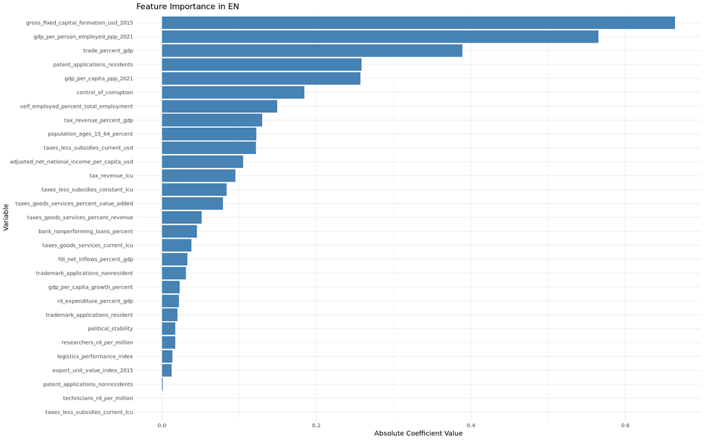

```r
coef_df <- as.data.frame(as.matrix(coef(elastic_net)))
coef_df$Variable <- rownames(coef_df)
colnames(coef_df) <- c("Coefficient", "Variable")

coef_df <- coef_df %>%
  filter(Variable != "(Intercept)") %>%
  arrange(desc(abs(Coefficient)))

ggplot(coef_df, aes(x = reorder(Variable, abs(Coefficient)), y = abs(Coefficient))) +
  geom_bar(stat = "identity", fill = "steelblue") +
  coord_flip() +
  labs(title = "Feature Importance in EN",
       x = "Variable", y = "Absolute Coefficient Value") +
  theme_minimal()
```

#### Variable Deduction via Elastic Net Including All Features in the Dataset

Selecting the variables to be kept for deeper Elastic Net analysis below and created 2 new features by combining 2 rows each (total_patent_applications and total_trademark_applications).

```r
wdi_wide_s <- wdi_wide_n %>%
  dplyr::select(
    "countryname",
    "countrycode",
    "year",
    "hightechexports",
    "taxes_less_subsidies_current_usd",
    "taxes_goods_services_percent_value_added",
    "gdp_per_person_employed_ppp_2021",
    "fdi_net_inflows_percent_gdp",
    "control_of_corruption",
    "gross_fixed_capital_formation_usd_2015",
    "political_stability",
    "rd_expenditure_percent_gdp",
    "trade_percent_gdp",
    "trademark_applications_nonresident",
    "trademark_applications_resident",
    "patent_applications_nonresidents",
    "patent_applications_residents",
     "logistics_performance_index",
      "population_ages_15_64_percent"
  ) %>%
  mutate(
    total_patent_applications = patent_applications_nonresidents + patent_applications_residents,
    total_trademark_applications = trademark_applications_nonresident + trademark_applications_resident
  ) %>%
  dplyr::select(
    -patent_applications_nonresidents,
    -patent_applications_residents,
    -trademark_applications_nonresident,
    -trademark_applications_resident
  )
```

### 4. Elastic Net Analysis with Selected Features and Country/Year dummies

This Elastic Net model includes both the selected features from the initial model and the country and year dummy variables. By incorporating these fixed effects, the model better accounts for country-specific and time-specific influences on high-tech exports, improving the robustness of feature selection.

```r
scaled_df <- wdi_wide_s %>%
  mutate(across(
    .cols = -c(countryname, countrycode, year),
    .fns = ~ scale(.x)[,1]
  ))

pdata_scaled <- pdata.frame(scaled_df, index = c("countryname", "year"))


X <- model.matrix(
  ~ . -1,
  data = pdata_scaled %>%
    dplyr::select(-hightechexports, -countrycode)
)

y <- pdata_scaled$hightechexports

cvfit <- cv.glmnet(X, y, alpha = 0.5)
coef(cvfit, s = "lambda.min")
```

```
52 x 1 sparse Matrix of class "dgCMatrix"
                                                   s1
(Intercept)                              -0.123130286
countrynameAustria                        0.038832119
countrynameBelgium                        0.271191810
countrynameBulgaria                       0.021359397
countrynameCroatia                        0.009374394
countrynameCyprus                         .
countrynameCzechia                        0.523285282
countrynameDenmark                       -0.097993706
countrynameEstonia                        .
countrynameFinland                       -0.167835268
countrynameFrance                         0.891005404
countrynameGermany                        1.304166074
countrynameGreece                        -0.092862533
countrynameIceland                       -0.090494907
countrynameIreland                        0.444050083
countrynameItaly                         -0.477766622
countrynameLatvia                         .
countrynameLithuania                     -0.016679451
countrynameLuxembourg                    -0.338924080
countrynameMalta                         -0.048779065
countrynameNetherlands                    1.336082354
countrynameNorway                        -0.294662001
countrynamePoland                         0.022038899
countrynamePortugal                      -0.102623970
countrynameRomania                       -0.013174662
countrynameSlovak Republic                0.099015843
countrynameSlovenia                      -0.021535686
countrynameSpain                         -0.290013212
countrynameSweden                         .
countrynameSwitzerland                    0.644749452
year2013                                  0.004481714
year2014                                  0.018278972
year2015                                  .
year2016                                  0.002249831
year2017                                 -0.026396681
year2018                                 -0.003769347
year2019                                  .
year2020                                 -0.019480554
year2021                                  0.031178250
taxes_less_subsidies_current_usd          0.343126604
taxes_goods_services_percent_value_added -0.031075807
gdp_per_person_employed_ppp_2021          0.060380691
fdi_net_inflows_percent_gdp              -0.002172643
control_of_corruption                     0.005827476
gross_fixed_capital_formation_usd_2015    0.050637800
political_stability                       .
rd_expenditure_percent_gdp                0.003957106
trade_percent_gdp                         0.001611292
logistics_performance_index               0.002563146
population_ages_15_64_percent            -0.005910833
total_patent_applications                 0.313545601
total_trademark_applications             -0.034505623
```

#### Calculating R-squared of Elastic Net with Selected Features and Country/Year Dummies

```r
X_with_dummies <- model.matrix(~ . -1,
                             data = pdata_scaled %>%
                               dplyr::select(-hightechexports, -countrycode))
y <- pdata_scaled$hightechexports

cvfit_with_dummies <- cv.glmnet(X_with_dummies, y, alpha = 0.5)
y_pred_with <- predict(cvfit_with_dummies,
                      newx = X_with_dummies,
                      s = "lambda.min")
r2_with <- cor(y, y_pred_with)^2

X_no_dummies <- model.matrix(~ . -1,
                           data = pdata_scaled %>%
                             dplyr::select(-hightechexports, -countrycode, -countryname, -year))

cvfit_no_dummies <- cv.glmnet(X_no_dummies, y, alpha = 0.5)
y_pred_without <- predict(cvfit_no_dummies,
                         newx = X_no_dummies,
                         s = "lambda.min")
r2_without <- cor(y, y_pred_without)^2

cat("R-squared WITH dummies:", round(r2_with, 3), "\n",
    "R-squared WITHOUT dummies:", round(r2_without, 3), "\n",
    "Difference:", round(r2_with - r2_without, 3))
```

```
R-squared WITH dummies: 0.99
 R-squared WITHOUT dummies: 0.915
 Difference: 0.075
```

#### Correlation and Coefficient Direction Check with Selected Variables from Elastic Net Analysis with Dummies

In this step, we cross-validated the direction and strength of the relationship between the selected features and the target variable (hightechexports). We calculated the Pearson correlation between each variable and the target, and compared it with the sign of the Elastic Net model coefficient. This allows us to check whether the model's direction (positive or negative effect) aligns with the actual data trend. Variables with mismatched signs or low coefficients can be flagged for removal or further inspection.

```r
selected_vars_enet <- c(
  "taxes_less_subsidies_current_usd",
  "taxes_goods_services_percent_value_added",
  "gdp_per_person_employed_ppp_2021",
  "fdi_net_inflows_percent_gdp",
  "control_of_corruption",
  "gross_fixed_capital_formation_usd_2015",
  "political_stability",
  "rd_expenditure_percent_gdp",
  "logistics_performance_index",
  "population_ages_15_64_percent",
  "total_patent_applications",
  "total_trademark_applications"
)

target_var <- "hightechexports"

correlations <- sapply(selected_vars_enet, function(var) {
  cor(pdata_scaled[[var]], pdata_scaled[[target_var]], use = "complete.obs")
})

enet_coef <- as.vector(coef(cvfit, s = "lambda.min"))
coef_names <- rownames(coef(cvfit, s = "lambda.min"))

model_coefs <- enet_coef[coef_names %in% selected_vars_enet]
names(model_coefs) <- coef_names[coef_names %in% selected_vars_enet]

comparison_df <- data.frame(
  Variable = names(model_coefs),
  Correlation = correlations[names(model_coefs)],
  Model_Coefficient = model_coefs
)

comparison_df$Direction_Match <- with(comparison_df, sign(Correlation) == sign(Model_Coefficient))

print(comparison_df)
```

```
                                                                         Variable
taxes_less_subsidies_current_usd                 taxes_less_subsidies_current_usd
taxes_goods_services_percent_value_added taxes_goods_services_percent_value_added
gdp_per_person_employed_ppp_2021                 gdp_per_person_employed_ppp_2021
fdi_net_inflows_percent_gdp                           fdi_net_inflows_percent_gdp
control_of_corruption                                       control_of_corruption
gross_fixed_capital_formation_usd_2015     gross_fixed_capital_formation_usd_2015
political_stability                                           political_stability
rd_expenditure_percent_gdp                             rd_expenditure_percent_gdp
logistics_performance_index                           logistics_performance_index
population_ages_15_64_percent                       population_ages_15_64_percent
total_patent_applications                               total_patent_applications
total_trademark_applications                         total_trademark_applications
                                         Correlation Model_Coefficient
taxes_less_subsidies_current_usd          0.88020138       0.343126604
taxes_goods_services_percent_value_added -0.53712917      -0.031075807
gdp_per_person_employed_ppp_2021          0.15386188       0.060380691
fdi_net_inflows_percent_gdp              -0.09263826      -0.002172643
control_of_corruption                     0.28418579       0.005827476
gross_fixed_capital_formation_usd_2015    0.90428471       0.050637800
political_stability                      -0.07683718       0.000000000
rd_expenditure_percent_gdp                0.40891514       0.003957106
logistics_performance_index               0.32932607       0.002563146
population_ages_15_64_percent            -0.21616454      -0.005910833
total_patent_applications                 0.89053527       0.313545601
total_trademark_applications              0.78773759      -0.034505623
                                         Direction_Match
taxes_less_subsidies_current_usd                    TRUE
taxes_goods_services_percent_value_added            TRUE
gdp_per_person_employed_ppp_2021                    TRUE
fdi_net_inflows_percent_gdp                         TRUE
control_of_corruption                               TRUE
gross_fixed_capital_formation_usd_2015              TRUE
political_stability                                FALSE
rd_expenditure_percent_gdp                          TRUE
logistics_performance_index                         TRUE
population_ages_15_64_percent                       TRUE
total_patent_applications                           TRUE
total_trademark_applications                       FALSE
```

#### Ploting Model Coefficients and Correlations

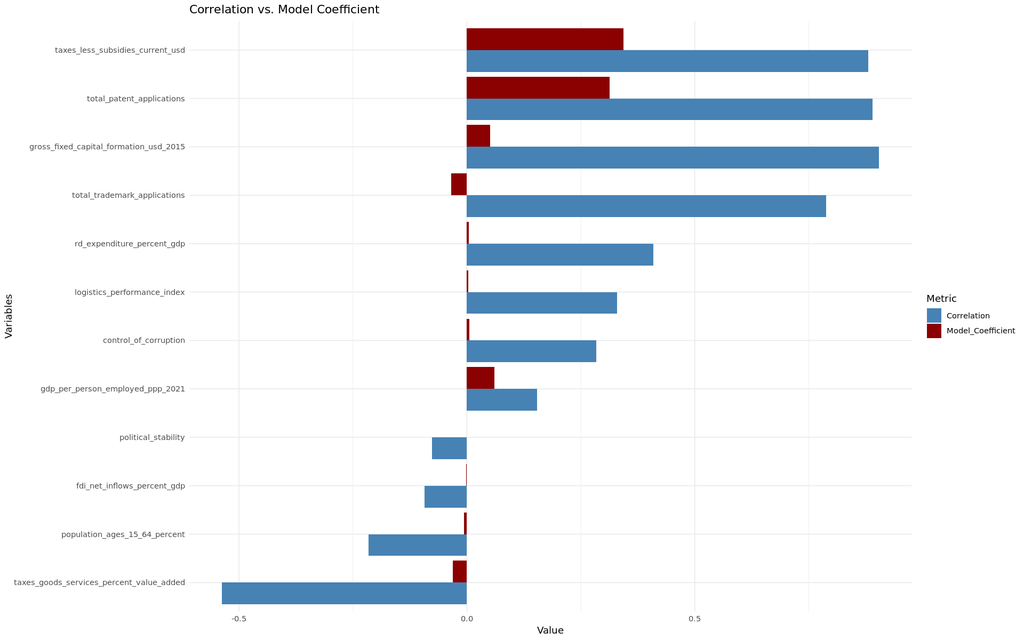

```r
result_df <- data.frame(
  Correlation = correlations[names(model_coefs)],
  Model_Coefficient = model_coefs,
  row.names = names(model_coefs)
)


df_plot <- result_df %>%
  rownames_to_column("Variable") %>%
  pivot_longer(cols = c("Correlation", "Model_Coefficient"),
               names_to = "Metric", values_to = "Value")

ggplot(df_plot, aes(x = reorder(Variable, Value), y = Value, fill = Metric)) +
  geom_bar(stat = "identity", position = "dodge") +
  coord_flip() +
  labs(title = "Correlation vs. Model Coefficient",
       x = "Variables", y = "Value") +
  scale_fill_manual(values = c("steelblue", "darkred")) +
  theme_minimal()
```

#### Variable Filtering Based on Model Coefficient and Correlation

We flagged variables with high correlation but opposite coefficient signs, or very low model impact, for removal.

```r
result_df$Direction_Match <- sign(result_df$Correlation) == sign(result_df$Model_Coefficient)

high_cor <- abs(result_df$Correlation) > 0.7
wrong_sign <- result_df$Direction_Match == FALSE
low_coef <- abs(result_df$Model_Coefficient) < 0.005

to_drop <- rownames(result_df)[(high_cor & wrong_sign) | low_coef]
print(to_drop)
```

```
[1] "fdi_net_inflows_percent_gdp"  "political_stability"
[3] "rd_expenditure_percent_gdp"   "logistics_performance_index"
[5] "total_trademark_applications"
```

### 5. PLM with excluded variables based on Model Coefficients and Correlations

```r
selected_vars_clean <- setdiff(rownames(result_df), to_drop)

model_formula_clean <- as.formula(
  paste("hightechexports ~", paste(selected_vars_clean, collapse = " + "))
)

model_clean <- plm(model_formula_clean, data = pdata_scaled, model = "within")

summary(model_clean, vcov = vcovHC)
```

```
Oneway (individual) effect Within Model

Note: Coefficient variance-covariance matrix supplied: vcovHC

Call:
plm(formula = model_formula_clean, data = pdata_scaled, model = "within")

Balanced Panel: n = 29, T = 10, N = 290

Residuals:
      Min.    1st Qu.     Median    3rd Qu.       Max.
-0.4222741 -0.0233419  0.0022188  0.0225353  0.6762882

Coefficients:
                                           Estimate Std. Error t-value
taxes_less_subsidies_current_usd          0.5219252  0.1785303  2.9235
taxes_goods_services_percent_value_added -0.0005642  0.0363438 -0.0155
gdp_per_person_employed_ppp_2021          0.2733414  0.0718879  3.8023
control_of_corruption                     0.0721990  0.0435599  1.6575
gross_fixed_capital_formation_usd_2015   -0.2774478  0.1777246 -1.5611
population_ages_15_64_percent             0.0094808  0.0285193  0.3324
total_patent_applications                 0.2783089  0.1560674  1.7833
                                          Pr(>|t|)
taxes_less_subsidies_current_usd         0.0037740 **
taxes_goods_services_percent_value_added 0.9876264
gdp_per_person_employed_ppp_2021         0.0001796 ***
control_of_corruption                    0.0986606 .
gross_fixed_capital_formation_usd_2015   0.1197427
population_ages_15_64_percent            0.7398361
total_patent_applications                0.0757378 .
---
Signif. codes:  0 ‘***’ 0.001 ‘**’ 0.01 ‘*’ 0.05 ‘.’ 0.1 ‘ ’ 1

Total Sum of Squares:    3.6586
Residual Sum of Squares: 2.7804
R-Squared:      0.24003
Adj. R-Squared: 0.13531
F-statistic: 9.53268 on 7 and 28 DF, p-value: 5.1309e-06
```

#### PLM Feature Importance Graph

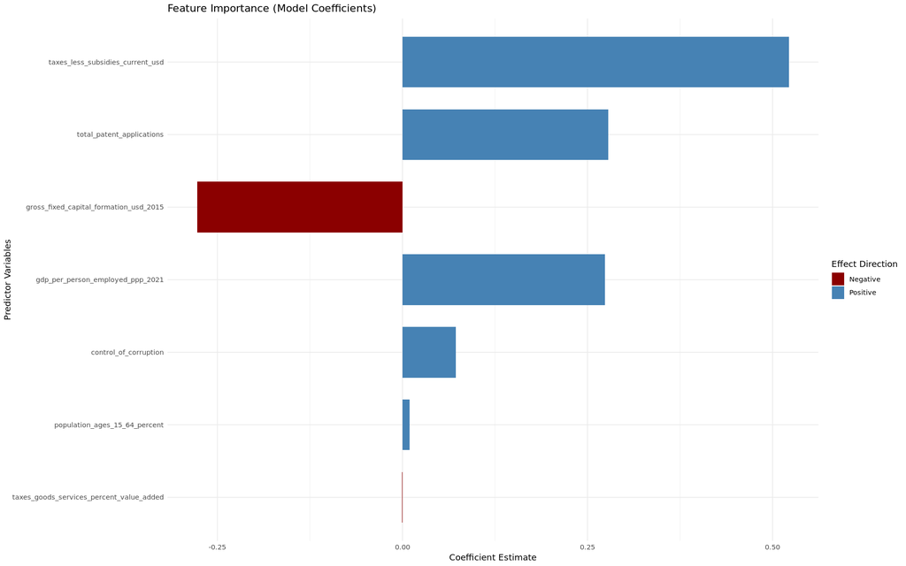

```r
coef_df <- tidy(model_clean)

coef_df <- coef_df %>%
  filter(term != "(Intercept)") %>%
  mutate(Direction = ifelse(estimate >= 0, "Positive", "Negative"))

coef_df$term <- reorder(coef_df$term, abs(coef_df$estimate))

ggplot(coef_df, aes(x = term, y = estimate, fill = Direction)) +
  geom_bar(stat = "identity", width = 0.7) +
  coord_flip() +
  scale_fill_manual(values = c("Positive" = "steelblue", "Negative" = "darkred")) +
  labs(
    title = "Feature Importance (Model Coefficients)",
    x = "Predictor Variables",
    y = "Coefficient Estimate",
    fill = "Effect Direction"
  ) +
  theme_minimal()
```

### 6. Multicollinearity Control with VIF

In the next step, we further refined our variable selection by applying a multicollinearity check using the Variance Inflation Factor (VIF). Variables with high VIF scores were excluded to improve model stability and interpretability. The updated variable set was then used to fit a new fixed effects (PLM) model.

```r
pdata_scaled <- pdata.frame(scaled_df, index = c("countryname", "year"))

predictors <- colnames(pdata_scaled)[
  !(colnames(pdata_scaled) %in% c("countryname", "countrycode", "year", "hightechexports"))
]

vif_formula <- as.formula(paste("hightechexports ~", paste(predictors, collapse = " + ")))
lm_model <- lm(vif_formula, data = pdata_scaled)

vif_values <- vif(lm_model)
print(vif_values)

selected_vars_vif <- names(vif_values[vif_values <= 5])
print("VIF'e göre seçilen değişkenler:")
print(selected_vars_vif)

model_formula_vif <- as.formula(
  paste("hightechexports ~", paste(selected_vars_vif, collapse = " + "))
)
model_plm_vif <- plm(model_formula_vif, data = pdata_scaled, model = "within")

summary(model_plm_vif, vcov = vcovHC)
```

```
        taxes_less_subsidies_current_usd
                               34.833117
taxes_goods_services_percent_value_added
                                3.019031
        gdp_per_person_employed_ppp_2021
                                3.320461
             fdi_net_inflows_percent_gdp
                                1.176577
                   control_of_corruption
                                4.555895
  gross_fixed_capital_formation_usd_2015
                               59.798489
                     political_stability
                                2.715767
              rd_expenditure_percent_gdp
                                3.281635
                       trade_percent_gdp
                                2.848785
             logistics_performance_index
                                1.488628
           population_ages_15_64_percent
                                1.897121
               total_patent_applications
                                5.383123
            total_trademark_applications
                                6.783618
[1] "VIF'e göre seçilen değişkenler:"
[1] "taxes_goods_services_percent_value_added"
[2] "gdp_per_person_employed_ppp_2021"
[3] "fdi_net_inflows_percent_gdp"
[4] "control_of_corruption"
[5] "political_stability"
[6] "rd_expenditure_percent_gdp"
[7] "trade_percent_gdp"
[8] "logistics_performance_index"
[9] "population_ages_15_64_percent"
```

```
Oneway (individual) effect Within Model

Note: Coefficient variance-covariance matrix supplied: vcovHC

Call:
plm(formula = model_formula_vif, data = pdata_scaled, model = "within")

Balanced Panel: n = 29, T = 10, N = 290

Residuals:
      Min.    1st Qu.     Median    3rd Qu.       Max.
-0.4855074 -0.0233978 -0.0013369  0.0227500  0.6659689

Coefficients:
                                           Estimate Std. Error t-value
taxes_goods_services_percent_value_added  0.0273189  0.0479161  0.5701
gdp_per_person_employed_ppp_2021          0.2150860  0.0436840  4.9237
fdi_net_inflows_percent_gdp              -0.0058706  0.0037932 -1.5477
control_of_corruption                     0.1313705  0.0511359  2.5690
political_stability                       0.0228664  0.0181322  1.2611
rd_expenditure_percent_gdp                0.0295955  0.0629937  0.4698
trade_percent_gdp                         0.1195891  0.0619905  1.9292
logistics_performance_index               0.0014644  0.0085119  0.1720
population_ages_15_64_percent             0.0093228  0.0308703  0.3020
                                          Pr(>|t|)
taxes_goods_services_percent_value_added   0.56909
gdp_per_person_employed_ppp_2021         1.537e-06 ***
fdi_net_inflows_percent_gdp                0.12296
control_of_corruption                      0.01077 *
political_stability                        0.20844
rd_expenditure_percent_gdp                 0.63889
trade_percent_gdp                          0.05483 .
logistics_performance_index                0.86354
population_ages_15_64_percent              0.76290
---
Signif. codes:  0 ‘***’ 0.001 ‘**’ 0.01 ‘*’ 0.05 ‘.’ 0.1 ‘ ’ 1

Total Sum of Squares:    3.6586
Residual Sum of Squares: 3.1461
R-Squared:      0.14008
Adj. R-Squared: 0.013818
F-statistic: 27.049 on 9 and 28 DF, p-value: 1.6018e-11
```

##### Finally, feature importance was visualized to highlight the relative contribution of each remaining variable.

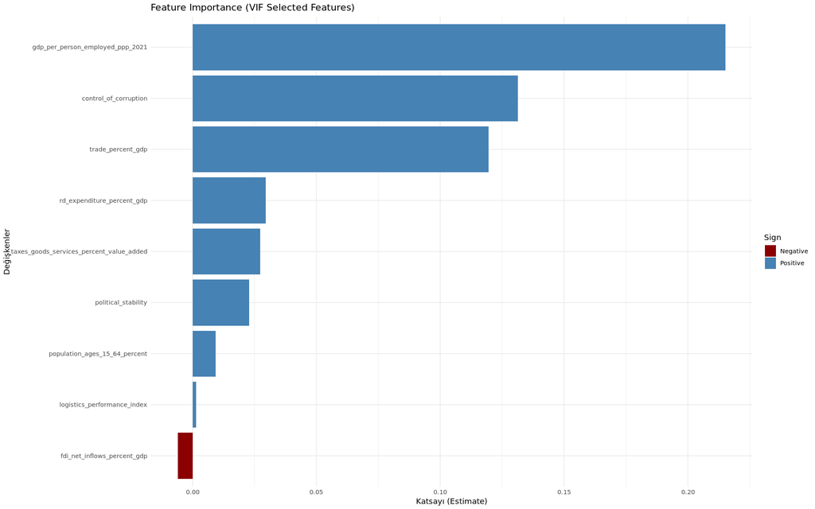

```r
coef_df <- tidy(model_plm_vif, conf.int = TRUE)

coef_df <- coef_df[coef_df$term != "(Intercept)", ]

coef_df$Sign <- ifelse(coef_df$estimate >= 0, "Positive", "Negative")

ggplot(coef_df, aes(x = reorder(term, estimate), y = estimate, fill = Sign)) +
  geom_col() +
  coord_flip() +
  labs(title = "Feature Importance (VIF Selected Features)",
       x = "Değişkenler",
       y = "Katsayı (Estimate)") +
  scale_fill_manual(values = c("Positive" = "steelblue", "Negative" = "darkred")) +
  theme_minimal()
```

### 7. Decision Tree Analysis

In this step, we built a decision tree model to explore the patterns behind high-tech exports. The features used in the tree were carefully selected based on previous steps, including Elastic Net regularization, correlation and coefficient direction checks, VIF-based multicollinearity analysis, and panel regression results. This ensured that the tree structure was both interpretable and statistically grounded.

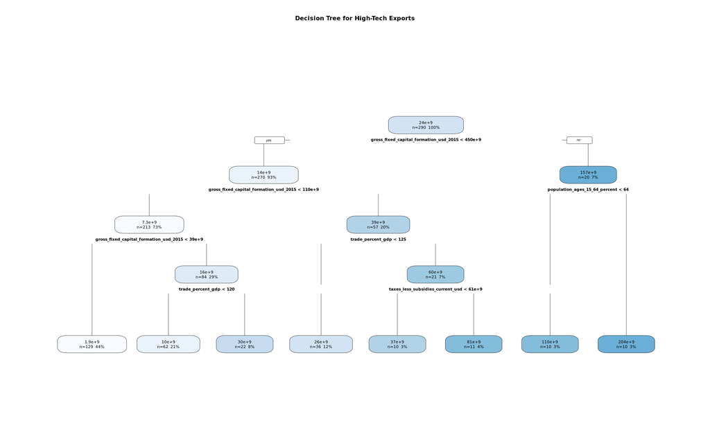

```r
tree_model <- rpart(
  formula = hightechexports ~ population_ages_15_64_percent +
                                    control_of_corruption +
                                    gross_fixed_capital_formation_usd_2015 +
                                    political_stability +
                                    taxes_less_subsidies_current_usd +
                                    gdp_per_person_employed_ppp_2021 +
                                    rd_expenditure_percent_gdp +
                                    trade_percent_gdp,
  data = wdi_wide_n,
  method = "anova"
)

rpart.plot(tree_model,
           type = 2,
           extra = 101,
           fallen.leaves = TRUE,
           main = "Decision Tree for High-Tech Exports")
```

#### Decision Tree Interprations

```r
print(tree_model)
```

```
n= 290

node), split, n, deviance, yval
      * denotes terminal node

 1) root 290 5.246430e+23  23745470000
   2) gross_fixed_capital_formation_usd_2015< 4.497313e+11 270 9.621824e+22  13857250000
     4) gross_fixed_capital_formation_usd_2015< 1.100347e+11 213 2.019691e+22   7257397000
       8) gross_fixed_capital_formation_usd_2015< 3.948557e+10 129 4.977272e+20   1876528000 *
       9) gross_fixed_capital_formation_usd_2015>=3.948557e+10 84 1.022821e+22  15520870000
        18) trade_percent_gdp< 120.336 62 2.367583e+21  10239850000 *
        19) trade_percent_gdp>=120.336 22 1.258475e+21  30403770000 *
     5) gross_fixed_capital_formation_usd_2015>=1.100347e+11 57 3.207349e+22  38519880000
      10) trade_percent_gdp< 125.4412 36 4.735691e+21  25934060000 *
      11) trade_percent_gdp>=125.4412 21 1.185957e+22  60095570000
        22) taxes_less_subsidies_current_usd< 6.073768e+10 10 8.829655e+20  37426930000 *
        23) taxes_less_subsidies_current_usd>=6.073768e+10 11 1.166417e+21  80703420000 *
   3) gross_fixed_capital_formation_usd_2015>=4.497313e+11 20 4.562870e+22 157236400000
     6) population_ages_15_64_percent< 63.99497 10 1.037897e+21 110463600000 *
     7) population_ages_15_64_percent>=63.99497 10 8.370608e+20 204009100000 *
```

#### Feature Importance for Decision Tree Analysis

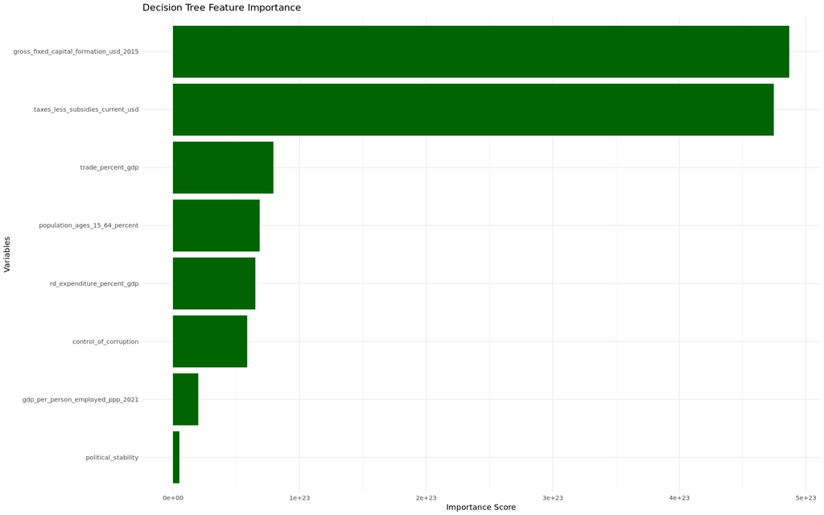

```r
importance_df <- data.frame(
  variable = names(tree_model$variable.importance),
  importance = tree_model$variable.importance
)

importance_df <- importance_df[order(importance_df$importance, decreasing = TRUE), ]

ggplot(importance_df, aes(x = reorder(variable, importance), y = importance)) +
  geom_col(fill = "darkgreen") +
  coord_flip() +
  labs(
    title = "Decision Tree Feature Importance",
    x = "Variables",
    y = "Importance Score"
  ) +
  theme_minimal()
```

### 8. Clustering Analysis

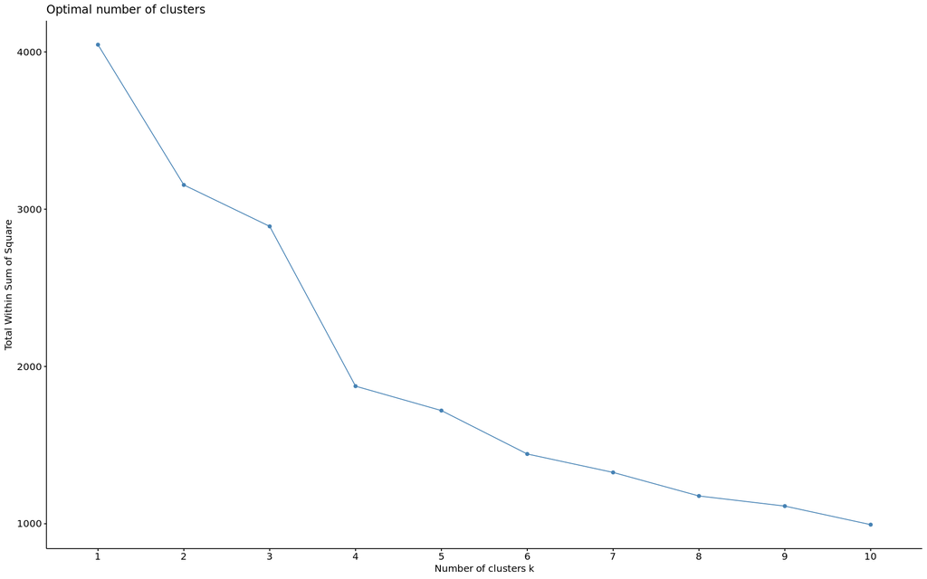

```r
df_clust <- wdi_wide_s %>%
  dplyr::select_if(is.numeric) %>%
  na.omit()

df_scaled <- scale(df_clust)

fviz_nbclust(df_scaled, kmeans, method = "wss")
```

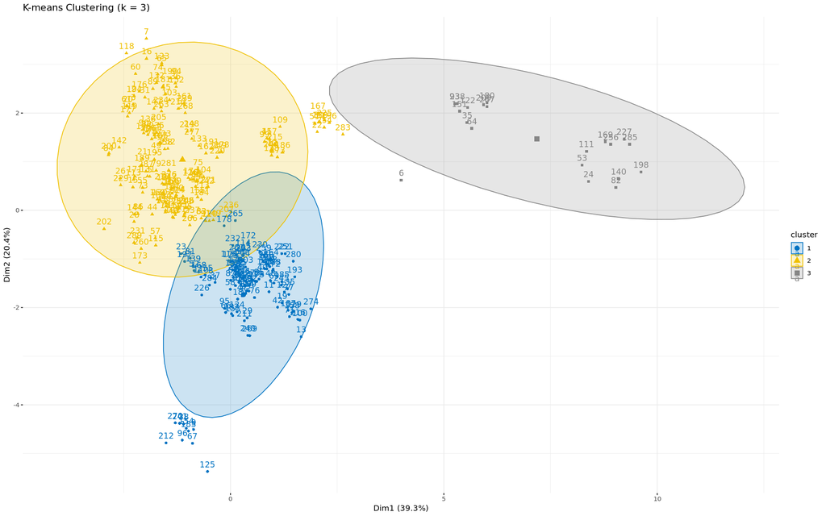

```r
set.seed(200)

pca_res <- prcomp(df_scaled)
pca_data <- pca_res$x[, 1:2]

kmeans_model <- kmeans(pca_data, centers = 3)

wdi_wide_n$cluster <- factor(kmeans_model$cluster)

fviz_cluster(
  kmeans_model,
  data = df_scaled,
  ellipse.type = "norm",
  palette = "jco",
  ggtheme = theme_minimal(),
  main = "K-means Clustering (k = 3)"
)
```

**Cluster 1 – Open & Wealthy Economies**

- Countries with high income levels and strong openness to international trade.
- GDP per capita: Highest (~72,522 USD)
- Trade openness: Highest (140%) → Strong export orientation
- R&D expenditure: High (2.35%)
- Political stability & corruption control: Strongest institutions

*High-tech exports: Moderate (~22.8 billion USD)*

Interpretation: These countries excel in exports and institutional strength but are not necessarily the top high-tech exporters.

**Cluster 2 – Transitional Economies**

*High-tech exports: Lowest (~7.5 billion USD)*

Interpretation: These countries are open to trade but lag in R&D and institutional quality.

**Cluster 3 – Tech-Driven Power Economies**

*High-tech exports: By far the highest (~157 billion USD)*

Interpretation: These economies rely less on trade openness and more on internal R&D and industrial capacity.

```r
wdi_wide_n %>%
  group_by(cluster) %>%
  summarise(
    avg_hightech = mean(hightechexports),
    avg_rd = mean(rd_expenditure_percent_gdp, na.rm = TRUE),
    avg_trade = mean(trade_percent_gdp, na.rm = TRUE),
    avg_gdp_percapita = mean(gdp_per_capita_ppp_2021, na.rm = TRUE),
    avg_polstablity = mean(political_stability, na.rm = TRUE),
    avg_agebtw_15_64 = mean(population_ages_15_64_percent, na.rm =TRUE),
    avg_cap_formation = mean(gross_fixed_capital_formation_usd_2015, na.rm = TRUE),
    avg_control_corruption = mean(control_of_corruption, na.rm = TRUE) ,
    .groups = "drop"
  )
```

A tibble: 3 × 9

| cluster <fct> | avg_hightech <dbl> | avg_rd <dbl> | avg_trade <dbl> | avg_gdp_percapita <dbl> | avg_polstablity <dbl> | avg_agebtw_15_64 <dbl> | avg_cap_formation <dbl> | avg_control_corruption <dbl> |
| --- | --- | --- | --- | --- | --- | --- | --- | --- |
| 1 | 22847592088 | 2.353910 | 140.65418 | 72522.56 | 1.0652895 | 65.51300 | 90500914774 | 1.8905974 |
| 2 | 7484355661 | 1.100548 | 120.35676 | 37428.33 | 0.6003147 | 66.35338 | 56179270652 | 0.4497991 |
| 3 | 157236352673 | 2.616177 | 70.51642 | 55897.97 | 0.4754339 | 63.94483 | 618628796470 | 1.5476453 |

#### Country Clusters based on 2021 data

```r
latest_clusters <- wdi_wide_n %>%
  group_by(countryname) %>%
  filter(year == max(year)) %>%
  ungroup() %>%
  dplyr::select(countryname, cluster) %>%
  distinct() %>%
  arrange(cluster, countryname)

print(latest_clusters, n = Inf)
```

```
# A tibble: 29 × 2
   countryname     cluster
   <chr>           <fct>
 1 Austria         1
 2 Belgium         1
 3 Czechia         1
 4 Denmark         1
 5 Finland         1
 6 Iceland         1
 7 Ireland         1
 8 Luxembourg      1
 9 Netherlands     1
10 Norway          1
11 Sweden          1
12 Switzerland     1
```

[output cut: 17 more lines]

#### Clusters of European Countries by High-Tech Characteristics (2021)

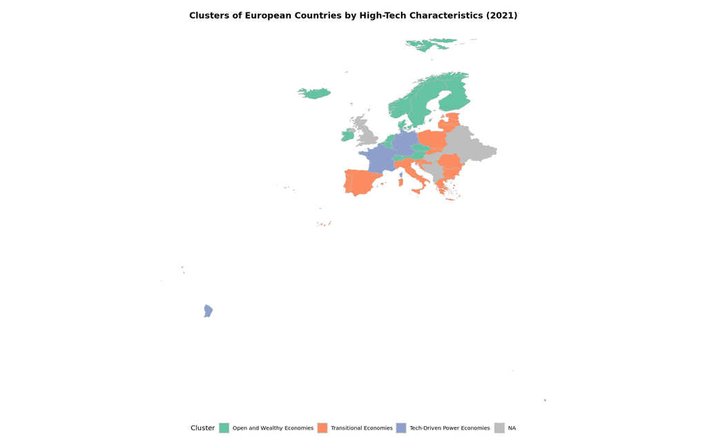

```r
world <- ne_countries(scale = "medium", returnclass = "sf")

europe <- world %>%
  filter(continent == "Europe") %>%
  filter(!sovereignt %in% c("Russia", "Turkey", "Kazakhstan", "Azerbaijan", "Armenia", "Georgia"))

df_cluster_years <- wdi_wide_n %>%
  dplyr::select(countryname, year, cluster) %>%
  distinct()


cluster_2021<- df_cluster_years %>%
  filter(year == 2021) %>%
  mutate(countryname = case_when(
    countryname == "United Kingdom" ~ "United Kingdom",
    countryname == "Bosnia & Herzegovina" ~ "Bosnia and Herzegovina",
    countryname == "Czech Republic" ~ "Czechia",
    countryname == "Slovak Republic" ~ "Slovakia",
    countryname == "Serbia" ~ "Republic of Serbia",
    countryname == "North Macedonia" ~ "North Macedonia",
    countryname == "Moldova" ~ "Moldova",
    countryname == "Hungary" ~ "Hungary",
    countryname == "Montenegro" ~ "Montenegro",
    countryname == "Albania" ~ "Albania",
    countryname == "Belarus" ~ "Belarus",
    TRUE ~ countryname
  ))

cluster_labels <- c(
  "1" = "Open and Wealthy Economies",
  "2" = "Transitional Economies",
  "3" = "Tech-Driven Power Economies"
)

cluster_2021$cluster_label <- factor(cluster_2021$cluster, labels = cluster_labels)

europe_clustered <- left_join(europe, cluster_2021, by = c("sovereignt" = "countryname"))

ggplot(europe_clustered) +
  geom_sf(aes(fill = cluster_label), color = "gray", size = 0.1) +
  scale_fill_brewer(palette = "Set2", na.value = "gray", name = "Cluster") +
  labs(title = "Clusters of European Countries by High-Tech Characteristics (2021)") +
  theme_void() +
  theme(
    legend.position = "bottom",
    plot.margin = unit(c(0.5, 0.5, 0.5, 0.5), "cm"),
    plot.title = element_text(hjust = 0.5, face = "bold", size = 14)
  ) +
  coord_sf(xlim = c(st_bbox(europe_clustered)$xmin, st_bbox(europe_clustered)$xmax),
           ylim = c(st_bbox(europe_clustered)$ymin, st_bbox(europe_clustered)$ymax))
```

### 9. Principal Component Analysis (PCA)

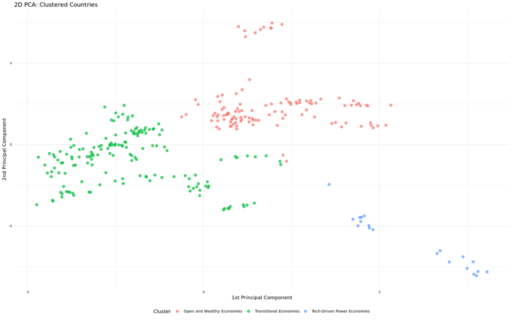

```r
wdi_wide_n$cluster_label <- factor(wdi_wide_n$cluster, labels = cluster_labels)

cluster_vec <- wdi_wide_n$cluster

df_pca_input <- wdi_wide_n %>%
  dplyr::select(where(is.numeric)) %>%
  dplyr::select(-hightechexports)

pca_res <- PCA(df_pca_input, graph = FALSE)

pca_coords <- as.data.frame(pca_res$ind$coord)
pca_coords$cluster_label <- wdi_wide_n$cluster_label

ggplot(pca_coords, aes(x = Dim.1, y = Dim.2, color = cluster_label)) +
  geom_point(alpha = 0.7, size = 2.5) +
  labs(
    title = "2D PCA: Clustered Countries",
    x = "1st Principal Component",
    y = "2nd Principal Component",
    color = "Cluster"
  ) +
  theme_minimal() +
  theme(legend.position = "bottom")
```

##### PCA Analysis on Countries Over Years

Visual below shows the trajectories of selected European countries on the PCA space from 2012 to 2021 based on macro-level indicators.

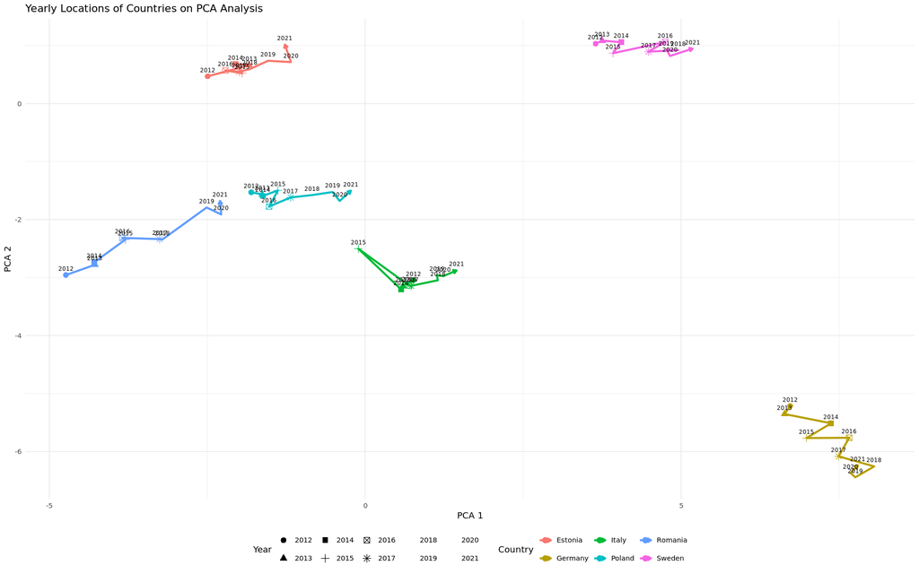

```r
example_countries <- c("Germany", "Poland", "Romania", "Sweden", "Italy", "Estonia")

pca_coords <- as.data.frame(pca_res$ind$coord)

pca_coords$countryname <- wdi_wide_n$countryname
pca_coords$year <- wdi_wide_n$year

set.seed(123)
kmeans_res <- kmeans(pca_coords[, 1:2], centers = 3)
pca_coords$cluster <- as.factor(kmeans_res$cluster)

pca_subset <- pca_coords %>%
  filter(countryname %in% example_countries)

ggplot(pca_subset, aes(x = Dim.1, y = Dim.2, group = countryname)) +
  geom_path(aes(color = countryname), size = 1.2, arrow = arrow(length = unit(0.15, "cm"), type = "closed")) +
  geom_point(aes(color = countryname, shape = as.factor(year)), size = 3) +
  geom_text(aes(label = year), size = 2.5, vjust = -1, color = "black") +
  theme_minimal() +
  labs(
    title = "Yearly Locations of Countries on PCA Analysis",
    x = "PCA 1",
    y = "PCA 2",
    shape = "Year",
    color = "Country"
  ) +
  theme(legend.position = "bottom")
```

##### Dimensional PCA Analysis

- Dim.1 (PC1) mainly represents economic and innovation capacity – countries with high GDP per capita, R&D spending, and capital formation score higher on this axis.
- Dim.2 (PC2) reflects institutional quality and demographics, such as political stability, control of corruption, and working-age population share.

Countries moving rightward over time on the PCA plot are improving economically; those moving upward are strengthening in governance and demographic structure.

*The position and trajectory of each country in the PCA space help visualize multidimensional development over time.*

A matrix: 30 × 5 of type dbl

|  | Dim.1 | Dim.2 | Dim.3 | Dim.4 | Dim.5 |
| --- | --- | --- | --- | --- | --- |
| adjusted_net_national_income_per_capita_usd | 0.73111811 | 0.53739562 | -0.141454178 | -0.0389097235 | 0.12134498 |
| bank_nonperforming_loans_percent | -0.51360089 | -0.28256913 | 0.007642333 | -0.0462679674 | 0.52831211 |
| control_of_corruption | 0.74847754 | 0.49886097 | -0.019933275 | -0.1356771679 | -0.05207810 |
| export_unit_value_index_2015 | -0.04813796 | -0.07151358 | 0.042489789 | 0.1211443388 | 0.07152998 |
| fdi_net_inflows_percent_gdp | -0.18060252 | 0.12148249 | -0.183382169 | 0.4344853645 | 0.37295288 |
| gdp_per_capita_growth_percent | -0.18320226 | 0.06839023 | -0.045437853 | 0.3091966413 | -0.15161392 |
| gdp_per_capita_ppp_2021 | 0.60303709 | 0.62043002 | -0.344611416 | 0.0004551142 | 0.19558325 |
| gdp_per_person_employed_ppp_2021 | 0.55202988 | 0.54115681 | -0.354645254 | -0.1201418677 | 0.28983433 |
| gross_fixed_capital_formation_usd_2015 | 0.68526210 | -0.62286809 | -0.296666146 | -0.0786294244 | 0.06004588 |
| hightechexportsratio | 0.29661732 | 0.14484098 | -0.038839857 | 0.4510631452 | 0.02892794 |
| logistics_performance_index | 0.54692245 | 0.09886111 | -0.071354260 | -0.2791798399 | 0.02397715 |
| patent_applications_nonresidents | 0.53027885 | -0.52617522 | -0.338095869 | -0.0240492485 | -0.09214397 |
| patent_applications_residents | 0.57409793 | -0.62300542 | -0.312202206 | -0.0512612702 | -0.03149716 |
| political_stability | 0.37918186 | 0.69716870 | -0.047423980 | 0.2072201504 | -0.23599096 |
| population_ages_15_64_percent | -0.33683871 | 0.21300572 | -0.437623560 | 0.4543896465 | 0.11164951 |
| rd_expenditure_percent_gdp | 0.75288867 | 0.11568022 | 0.230072494 | -0.3543915387 | -0.10681681 |
| researchers_rd_per_million | 0.71561349 | 0.41242835 | 0.252386756 | -0.3244337681 | -0.05420595 |
| self_employed_percent_total_employment | -0.47399615 | -0.37898627 | -0.008257336 | -0.0755014760 | 0.37565881 |
| tax_revenue_percent_gdp | 0.02802366 | 0.37952193 | 0.454415724 | -0.3070259128 | 0.59830674 |
| tax_revenue_lcu | 0.66929595 | -0.04725522 | 0.652847919 | 0.2660008285 | 0.13246577 |
| taxes_less_subsidies_constant_lcu | 0.71332511 | -0.20779220 | 0.536383575 | 0.3253584085 | 0.05995252 |
| taxes_less_subsidies_current_lcu | 0.70122219 | -0.21169589 | 0.545993987 | 0.3372746020 | 0.05797947 |
| taxes_less_subsidies_current_usd | 0.63066054 | -0.67088009 | -0.221455148 | -0.1195669344 | 0.13938718 |
| taxes_goods_services_percent_revenue | -0.59008999 | 0.13629756 | 0.423093760 | -0.0671609714 | -0.38118840 |
| taxes_goods_services_percent_value_added | -0.55226433 | 0.11641911 | 0.524438070 | -0.3561488416 | 0.02294389 |
| taxes_goods_services_current_lcu | 0.63915308 | -0.08402496 | 0.642298344 | 0.3490951461 | 0.06494624 |
| technicians_rd_per_million | 0.38223924 | 0.20833625 | -0.258147220 | -0.1407212030 | -0.02126078 |
| trade_percent_gdp | -0.14002357 | 0.63572081 | -0.477010007 | 0.1778173729 | 0.11716072 |
| trademark_applications_nonresident | 0.49743116 | -0.08561093 | -0.320113207 | 0.1172259157 | -0.28276541 |
| trademark_applications_resident | 0.54144849 | -0.64660984 | -0.265906705 | -0.0661408761 | 0.09199836 |

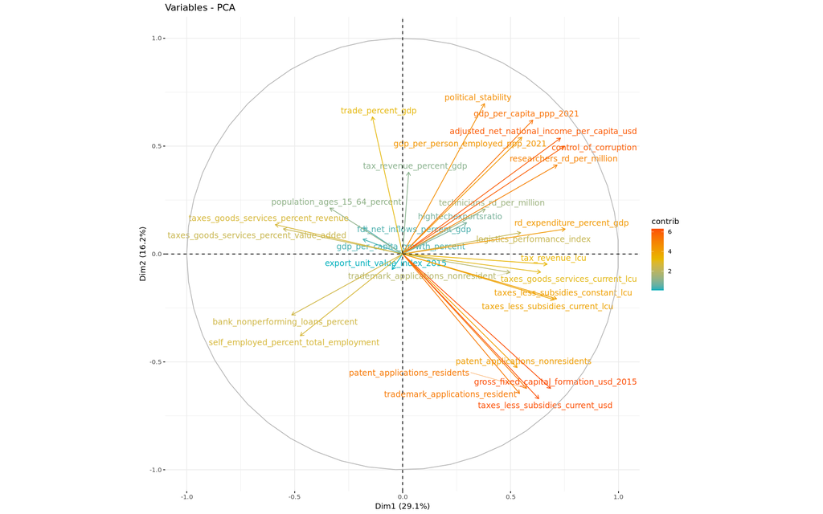

```r
fviz_pca_var(pca_res,
             col.var = "contrib",
             gradient.cols = c("#00AFBB", "#E7B800", "#FC4E07"),
             repel = TRUE)

pca_res$var$coord
```

## Conclusion

Clustering analysis grouped countries into three distinct profiles: (1) open and wealthy economies with high trade and stability, (2) transitional economies with lower R&D and exports, and (3) tech-driven powerhouses like Germany, characterized by high production investment and innovation capacity.

PCA results visually confirmed these groupings and illustrated country trajectories over time, highlighting structural improvements in some countries and stagnation or volatility in others. Overall, the findings show that sustained investment in innovation, economic openness, and institutional strength are critical to boosting high-tech export capacity in Europe.